# Cardiovascular risk prediction

### VARIABLES CATEGORICAS - TARGET - GRAFICO DE BARRAS - APILADAS

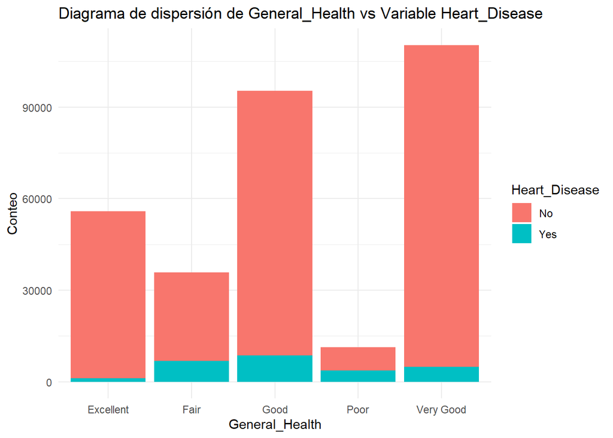

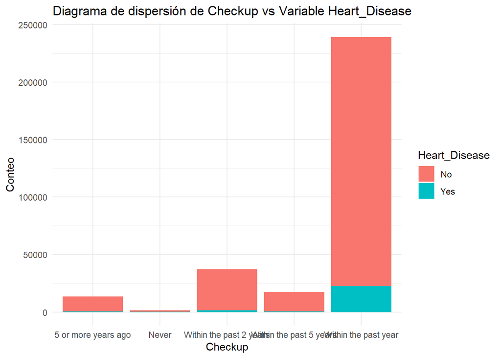

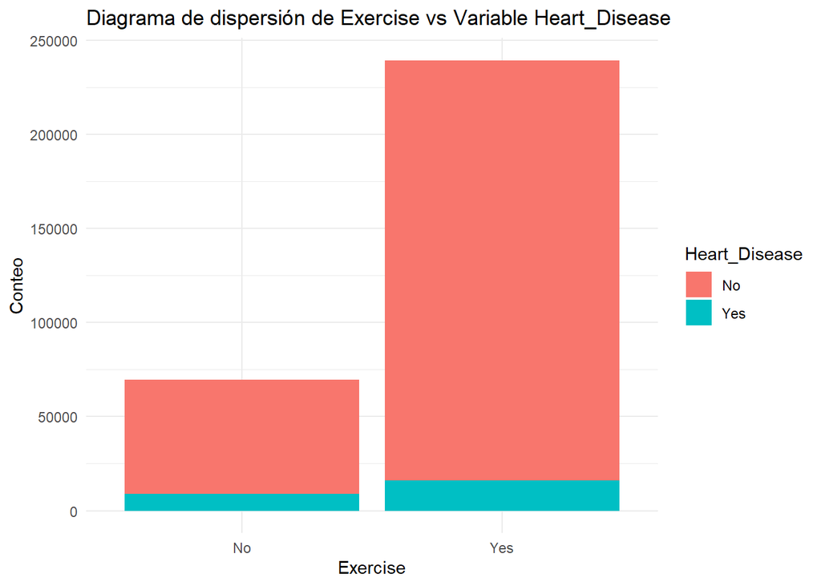

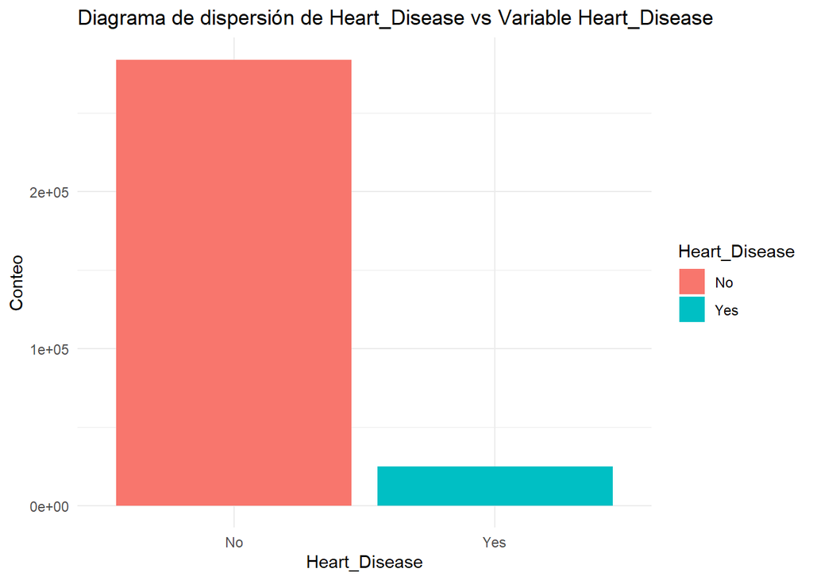

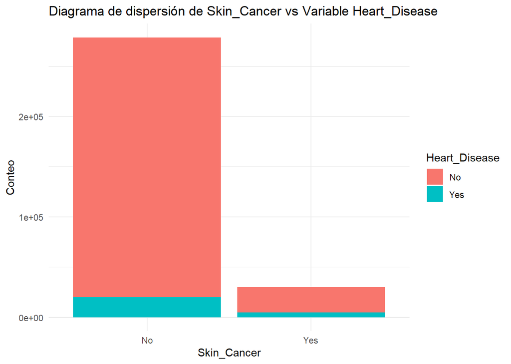

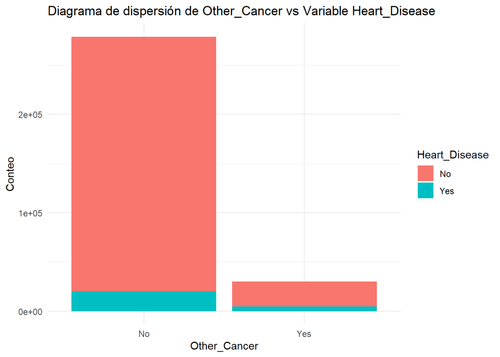

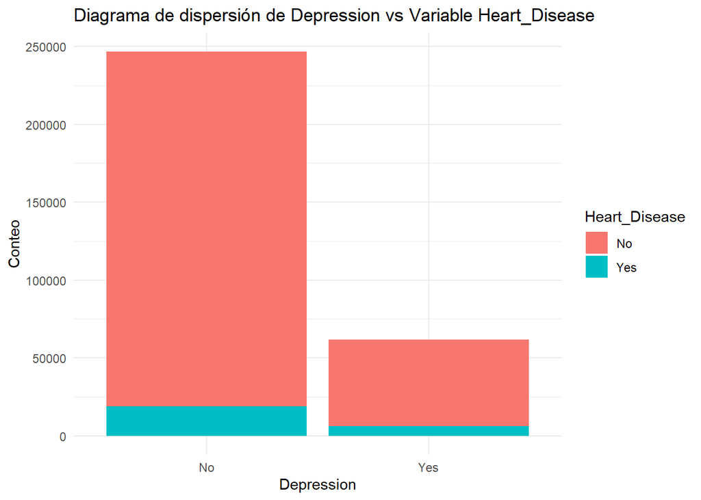

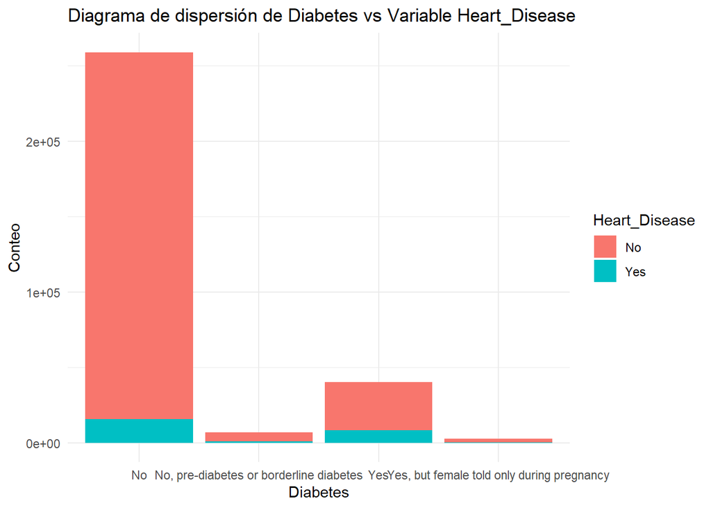

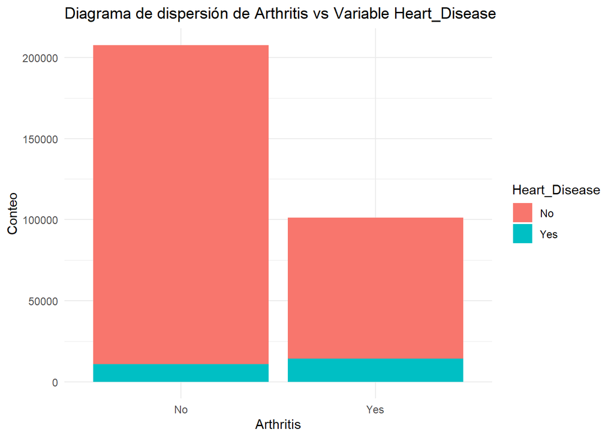

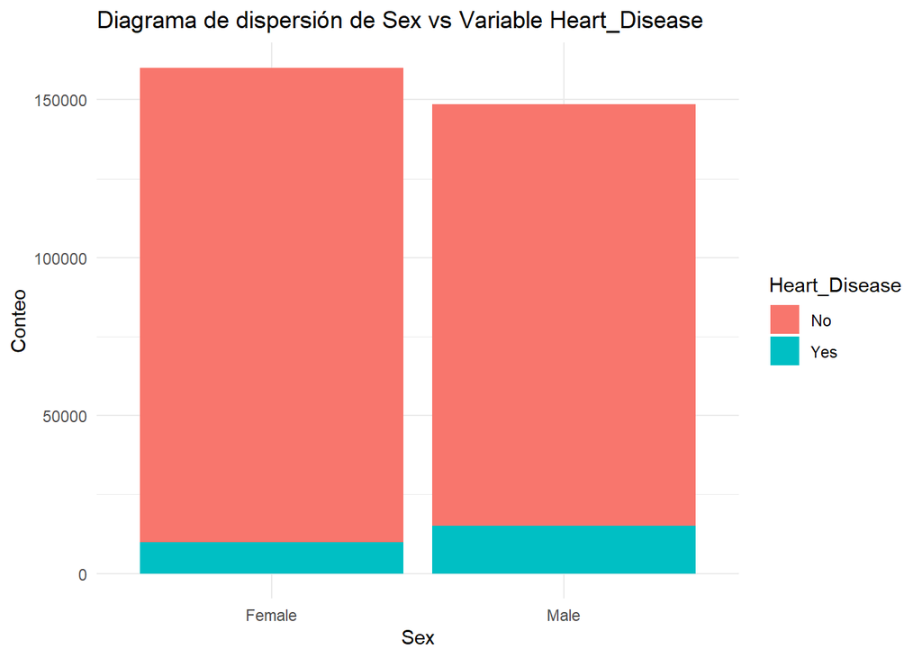

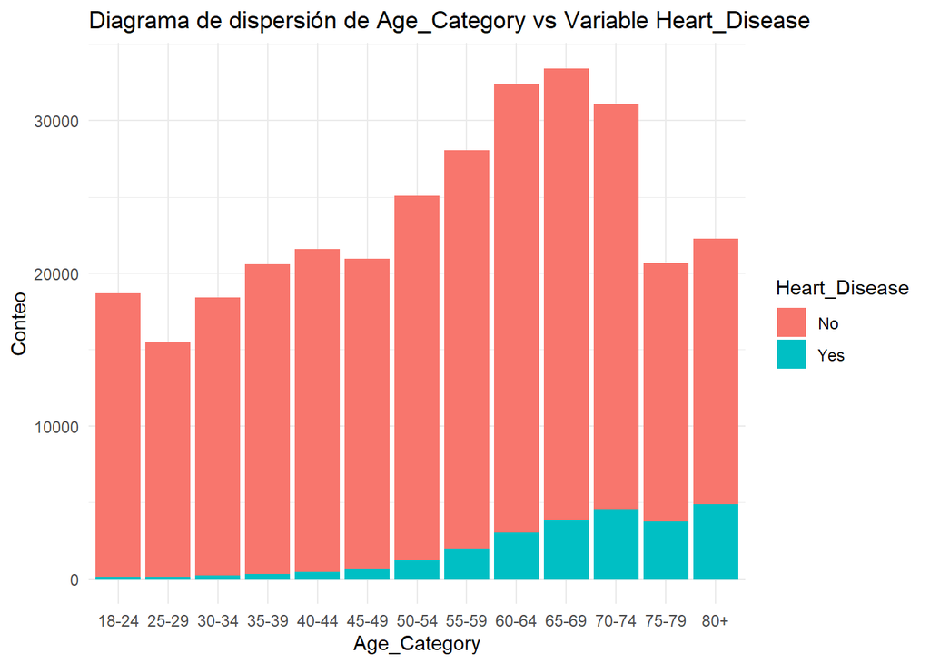

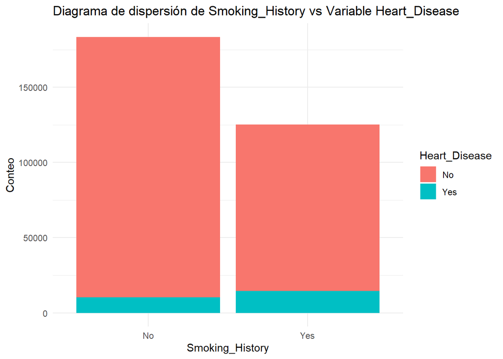

```r
variables_categoricas = data %>%
  select(where(is.factor))

for (var in colnames(variables_categoricas)) {
  g = ggplot(data, aes(x = variables_categoricas[[var]], fill = Heart_Disease)) +
    theme_minimal() +
    geom_bar(position = "stack") +
    labs(x = var, y = "Conteo", fill = "Heart_Disease") +
    ggtitle(paste("Diagrama de dispersión de", var, "vs Variable Heart_Disease"))

  print(g)

}
```

EL GRAFICO DE BARRAS APILADAS ME GUSTA MUCHO PORQUE NO OCUPA TANTO ESPACIO (CUANDO HAY MUCHOS NIVELES EN UNA VARIABLE CATEGORICA) Y TE DICE LA MISMA INFORMACIÓN QUE EL DE BARRAS NORMAL.

### VARIABLES CATEGORICAS - TARGET - MOSAICO PLOT

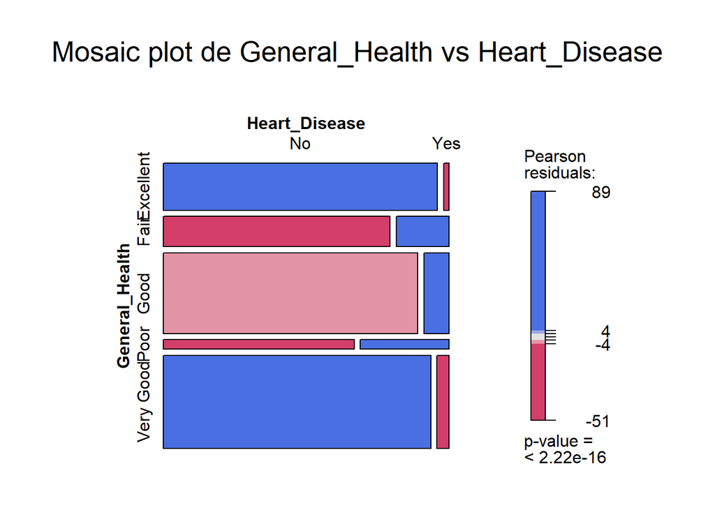

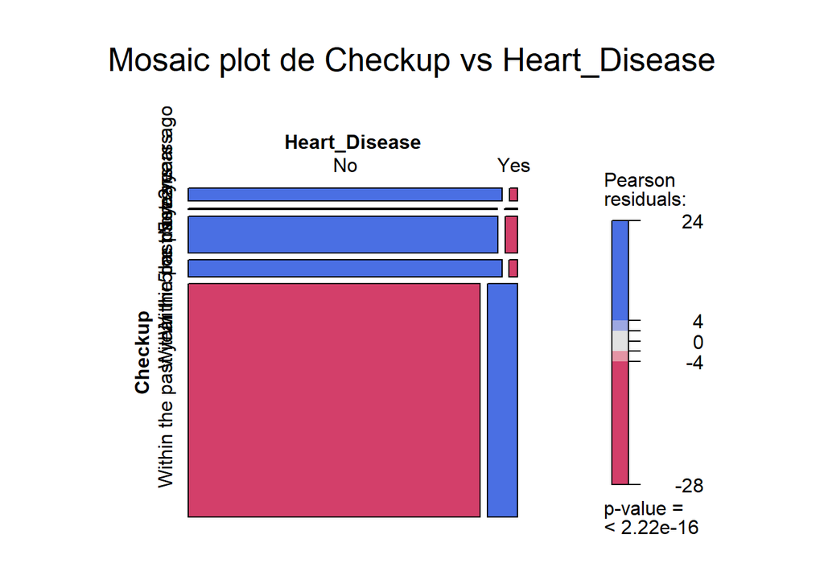

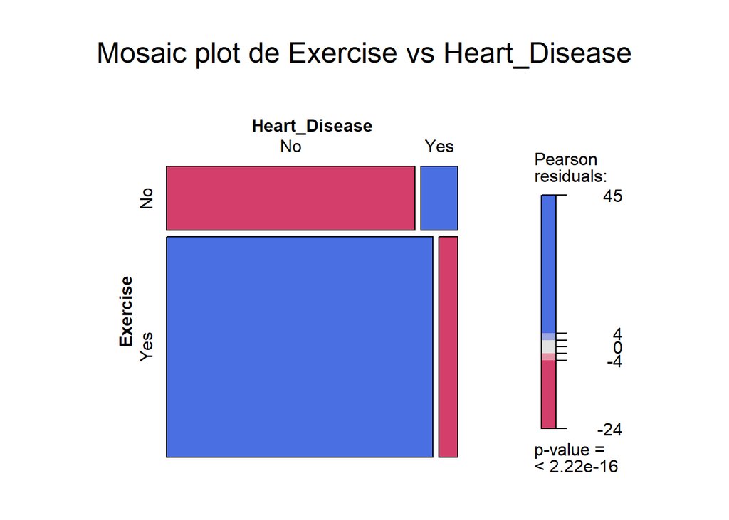

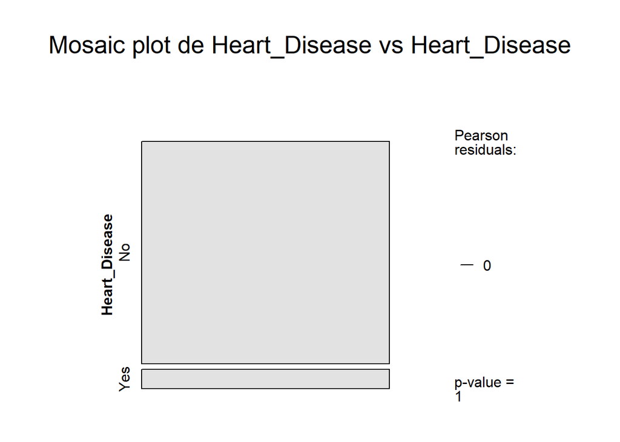

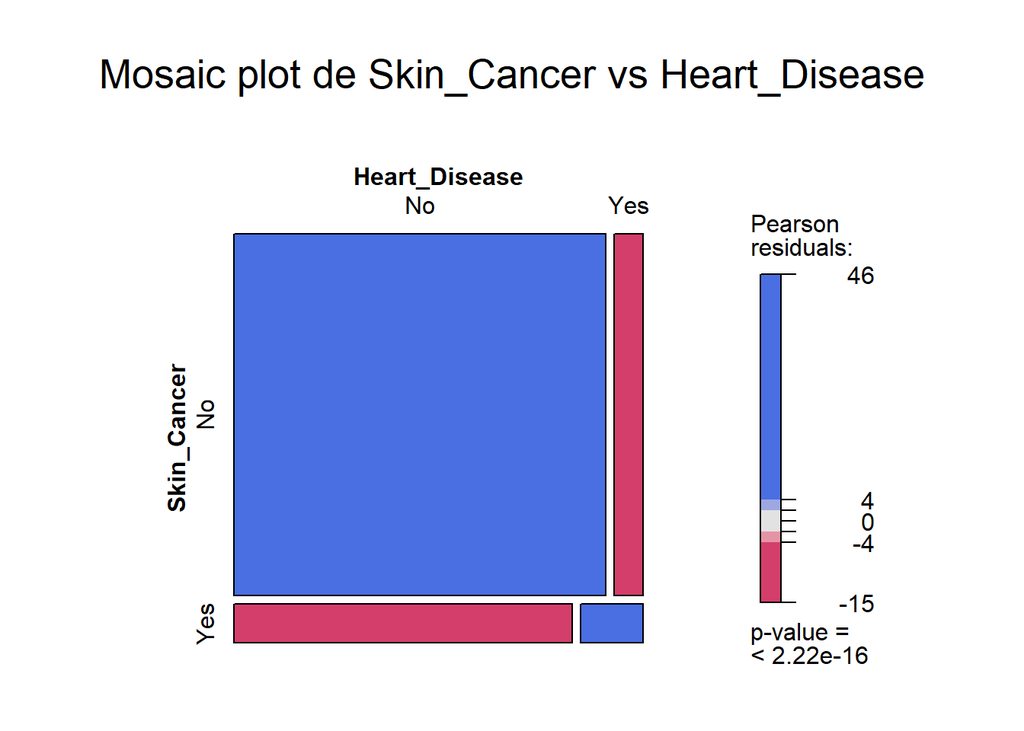

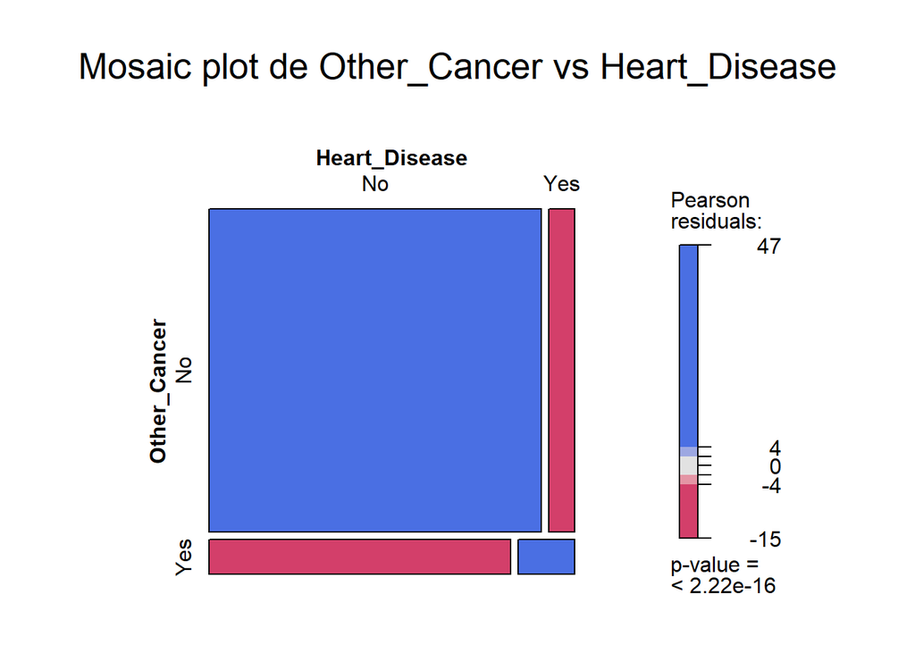

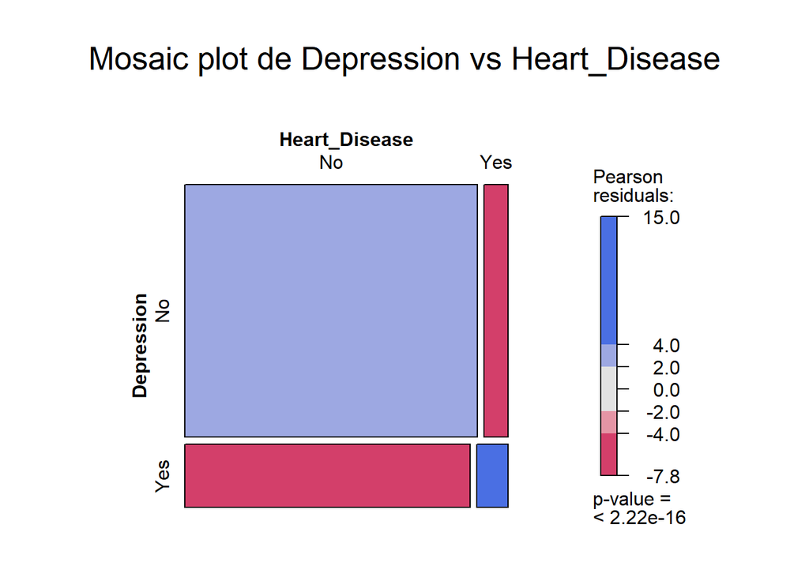

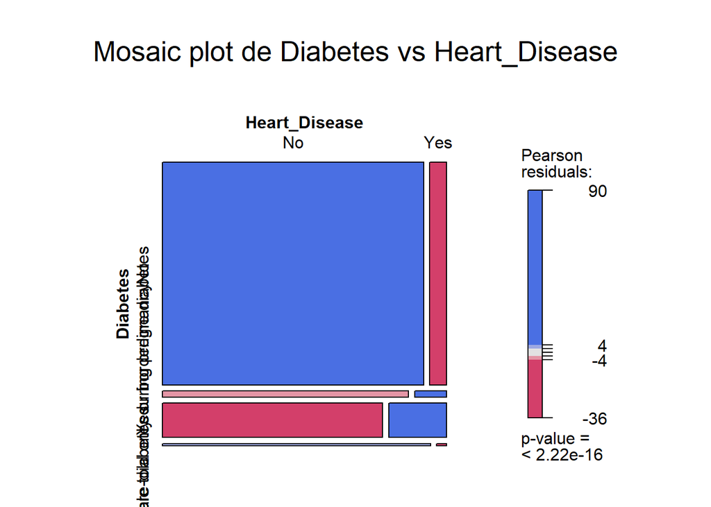

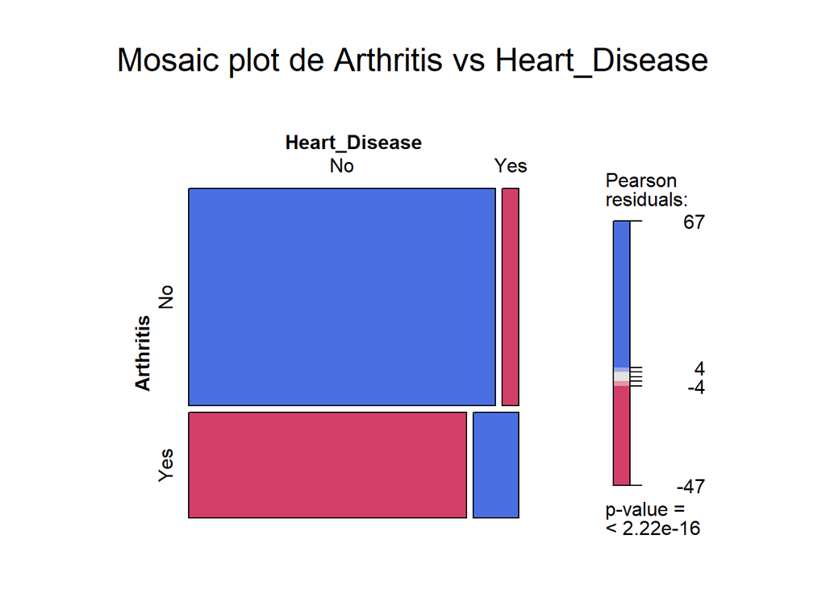

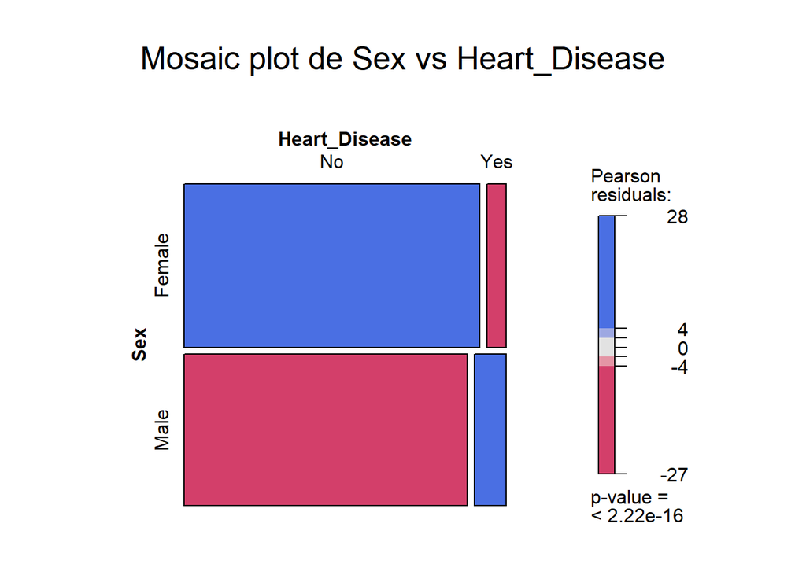

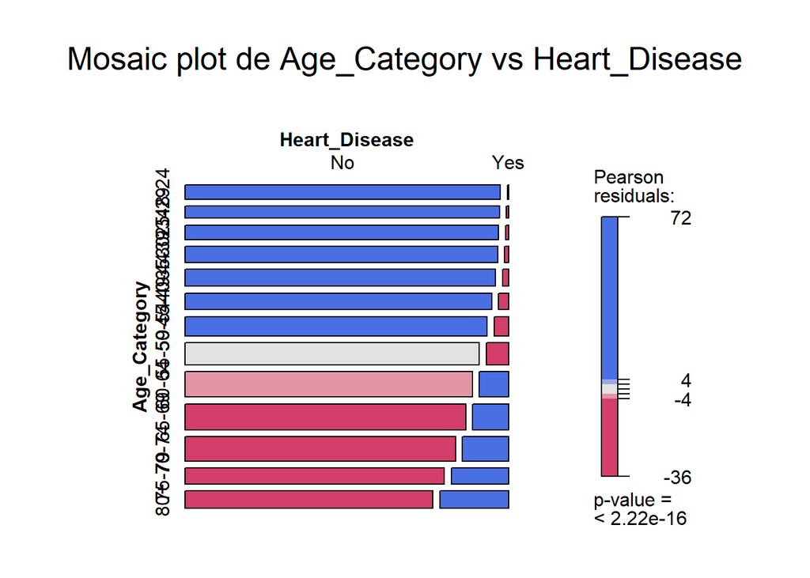

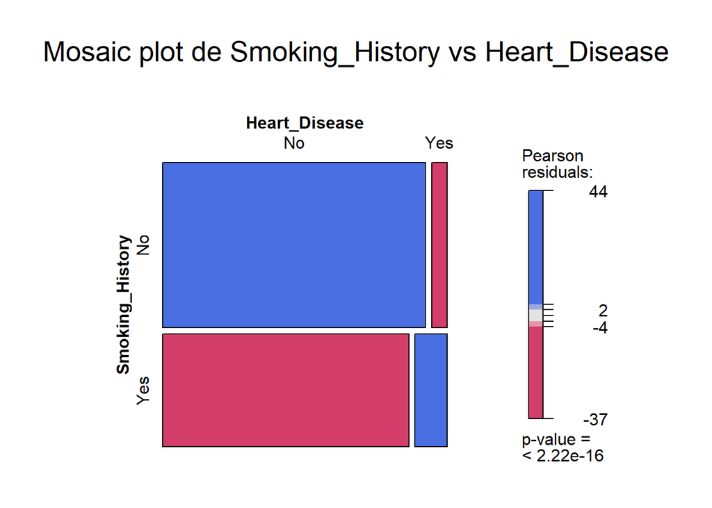

```r
# Seleccionar las variables categóricas del dataset
variables_categoricas = data %>%
  select(where(is.factor))

# Crear un bucle para iterar sobre cada variable categórica
for (var in colnames(variables_categoricas)) {

  # Crear la fórmula dinámica para el mosaic plot
  formula_mosaico = as.formula(paste("~", var, "+ Heart_Disease"))

  # Generar el mosaic plot
  mosaic(formula_mosaico, data = data, shade = TRUE,
         main = paste("Mosaic plot de", var, "vs Heart_Disease"))
}
```

LOS MOSAICO PLOTS SON MUY UTILES PARA VISUALIZAR LA RELACION ENTRE DOS O INCLUSO MÁS VARIABLES. ESTE GRAFICO SE DESCOMPONE EN UN RECTANGULO DE BLOQUES QUE REPRESENTAN LAS FRECUENCIAS DE CADA COMBINACIÓN DE LAS VARIABLES CATEGORICAS. ADEMÁS, TE DA LOS RESIDUOS Y EL P-VALOR DE ESTOS.

### VARIABLES CATEGORICAS - TARGET - Proportional bar chart

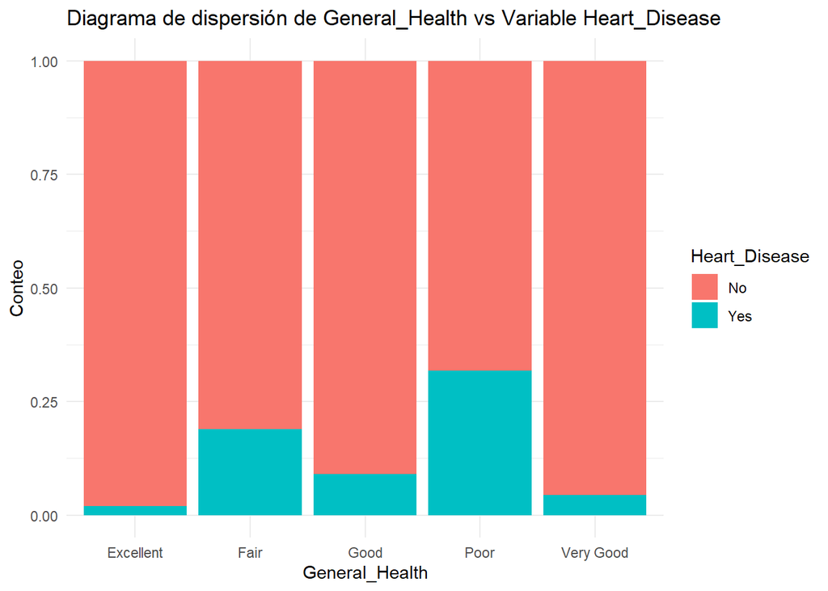

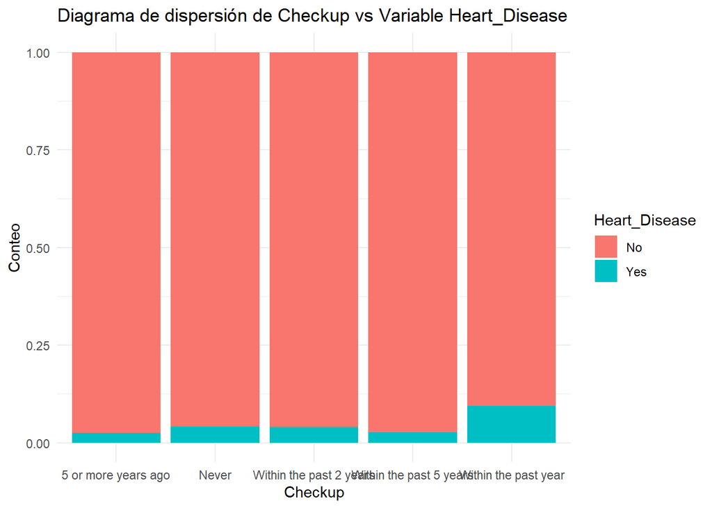

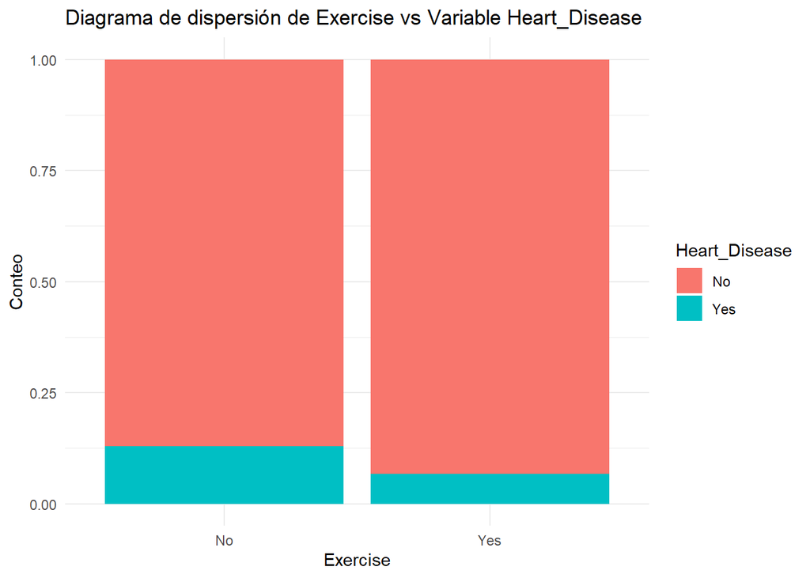

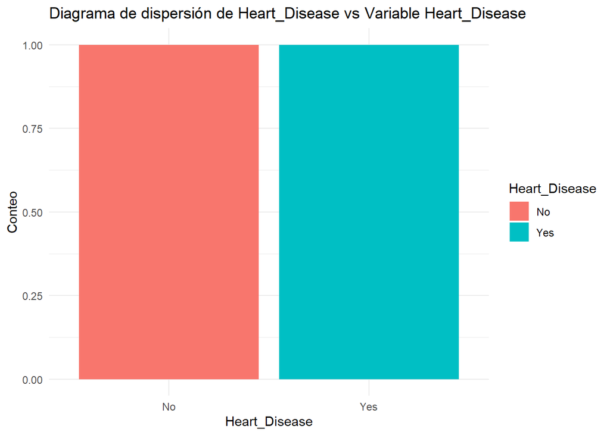

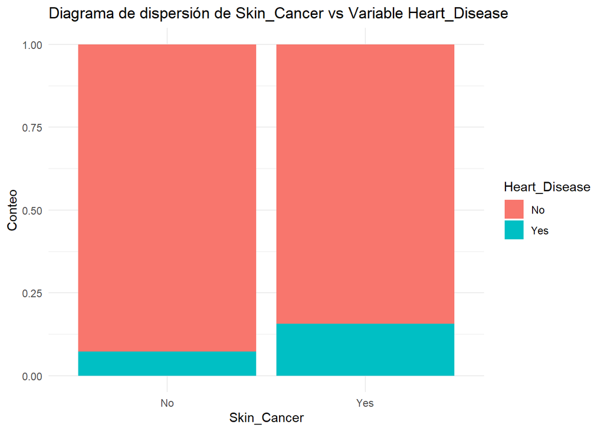

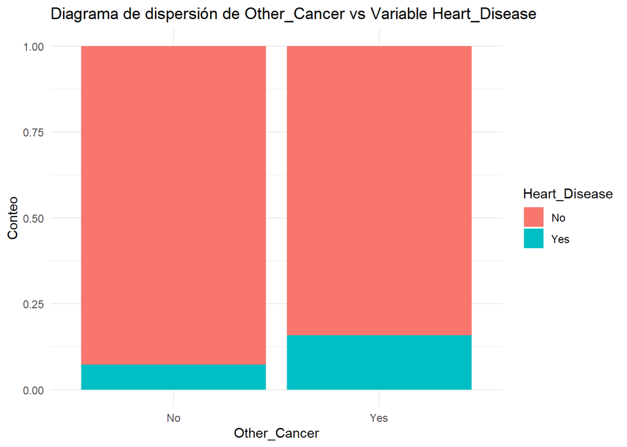

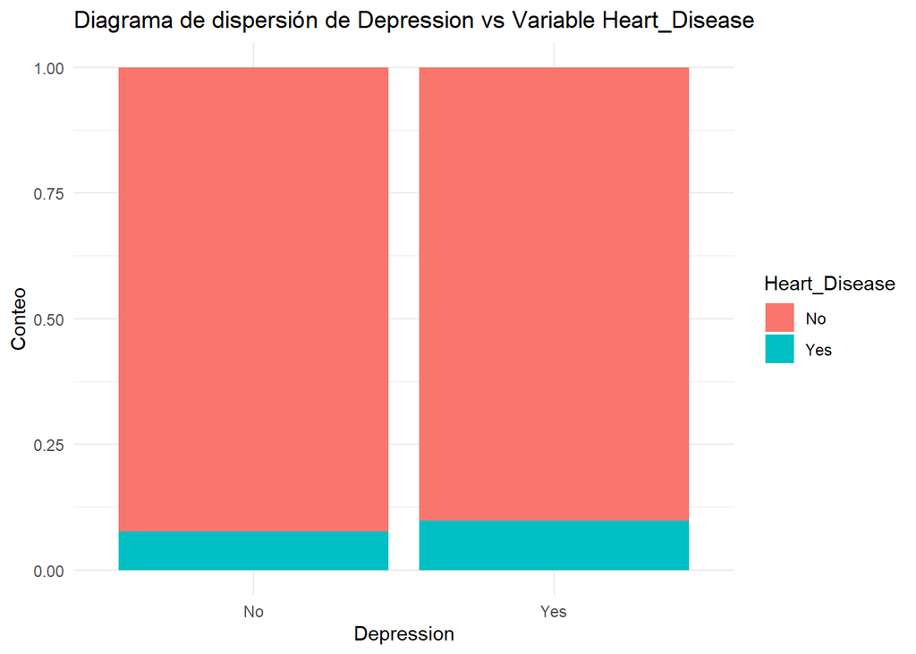

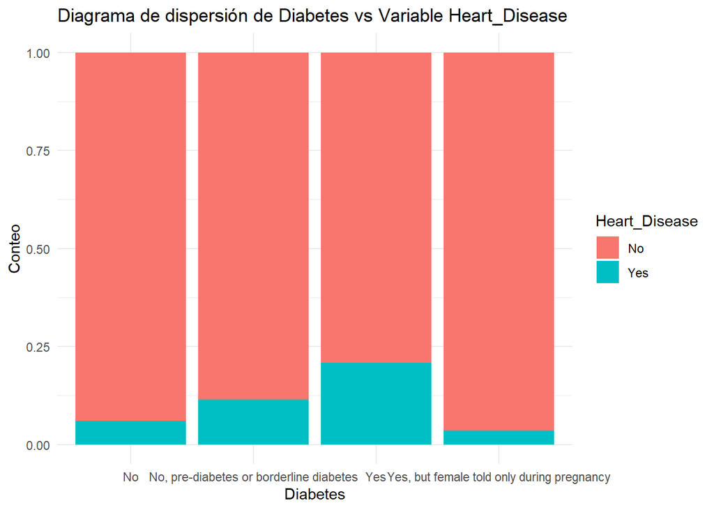

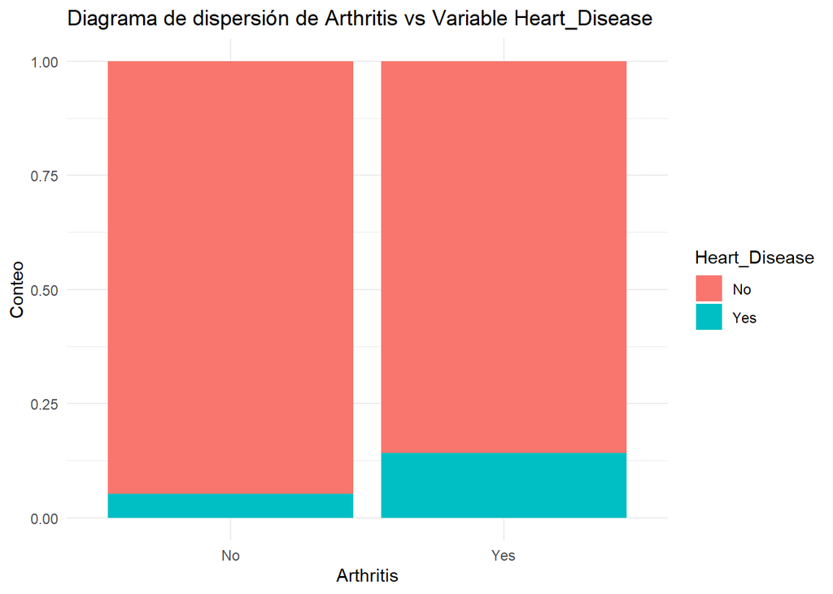

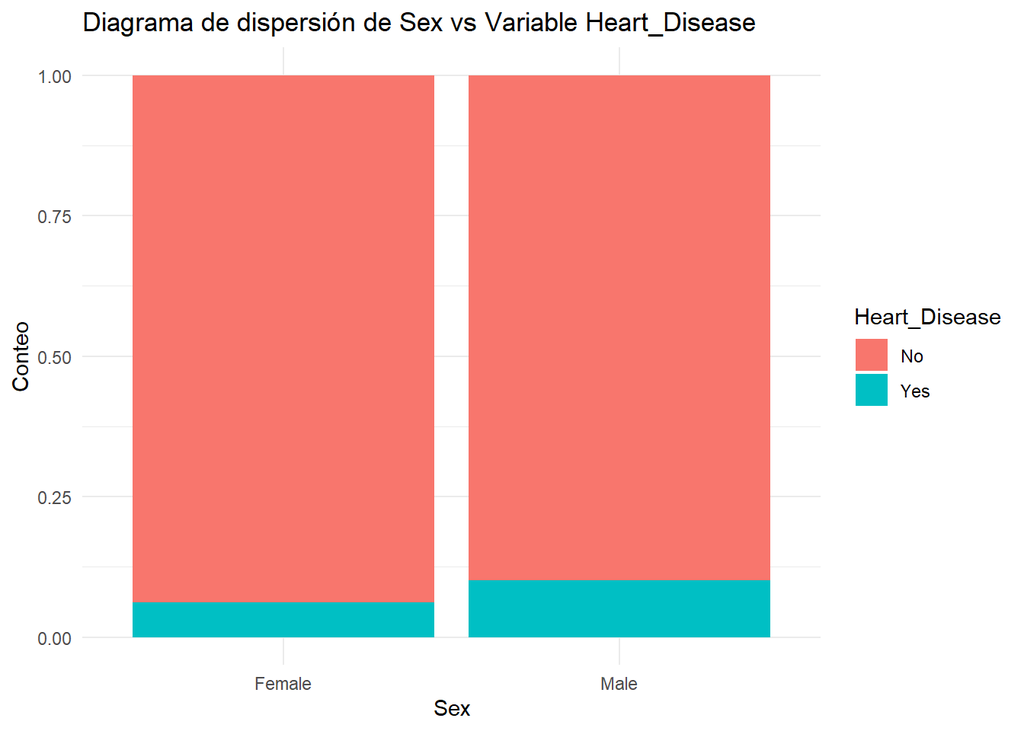

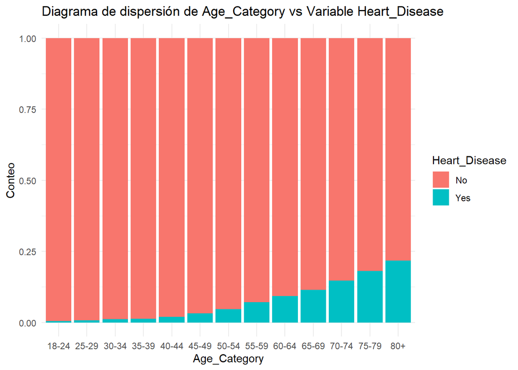

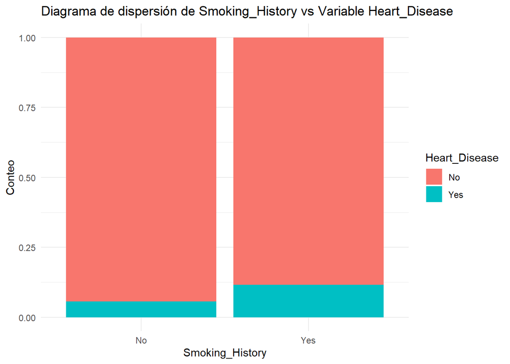

```r
variables_categoricas = data %>%
  select(where(is.factor))

for (var in colnames(variables_categoricas)) {
  g = ggplot(data, aes(x = variables_categoricas[[var]], fill = Heart_Disease)) +
    theme_minimal() +
    geom_bar(position = "fill") +
    labs(x = var, y = "Conteo", fill = "Heart_Disease") +
    ggtitle(paste("Diagrama de dispersión de", var, "vs Variable Heart_Disease"))

  print(g)

}
```

ES UN GRAFICO DE BARRAS APILADAS PERO POR PROPORCIONES, DONDE SE VA A VER REFLEJADO DE MEJOR MANERA LOS RESULTADOS EN VARIABLES COMO LA EDAD.

### VARIABLES CATEGORICAS - TARGET - HEATMAP

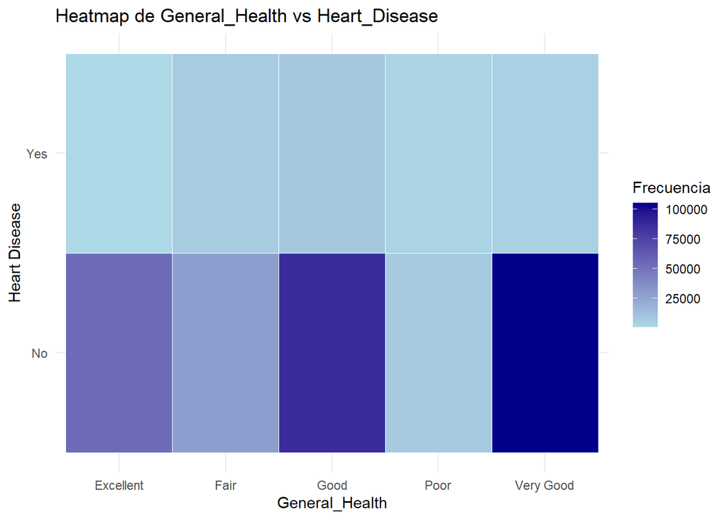

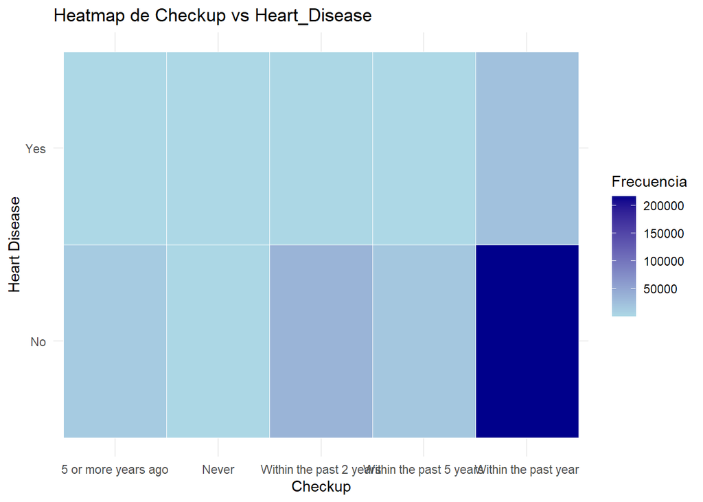

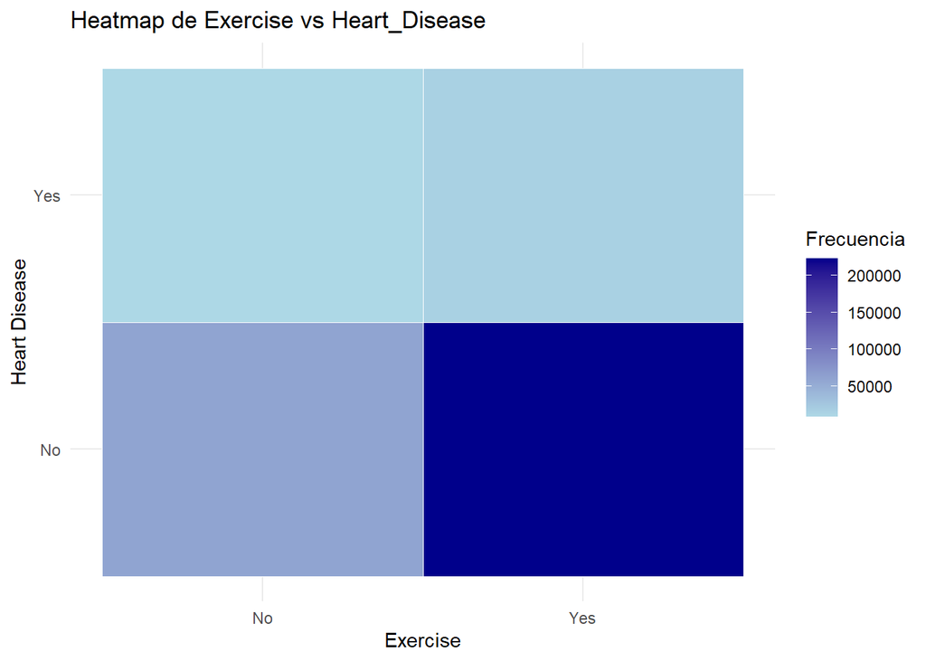

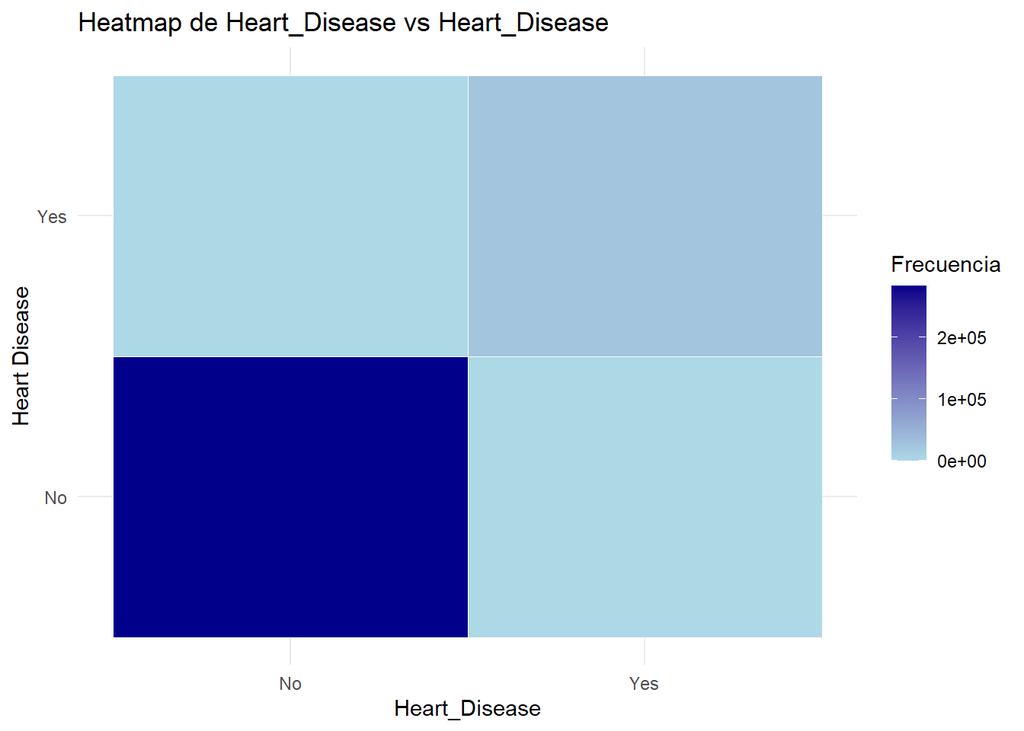

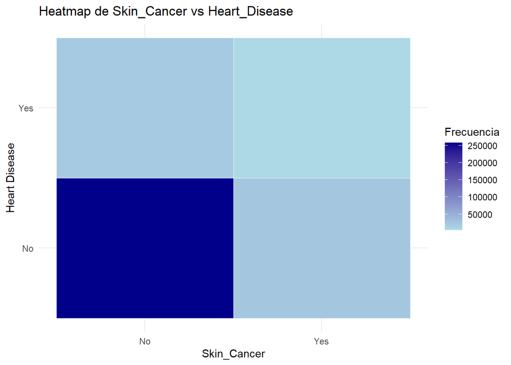

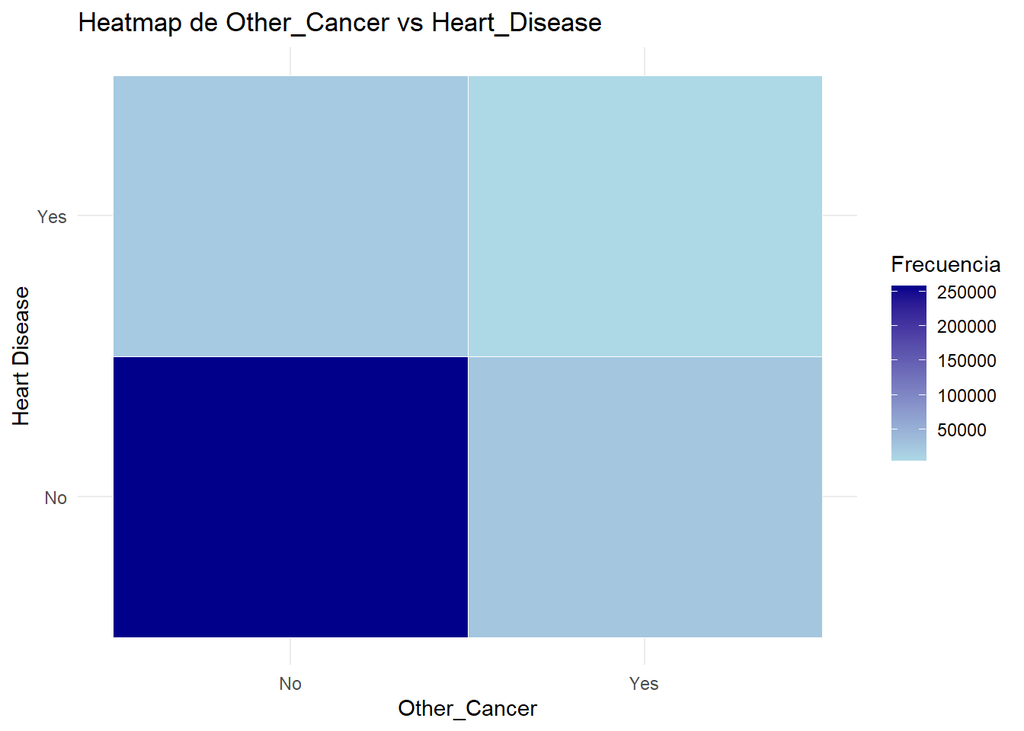

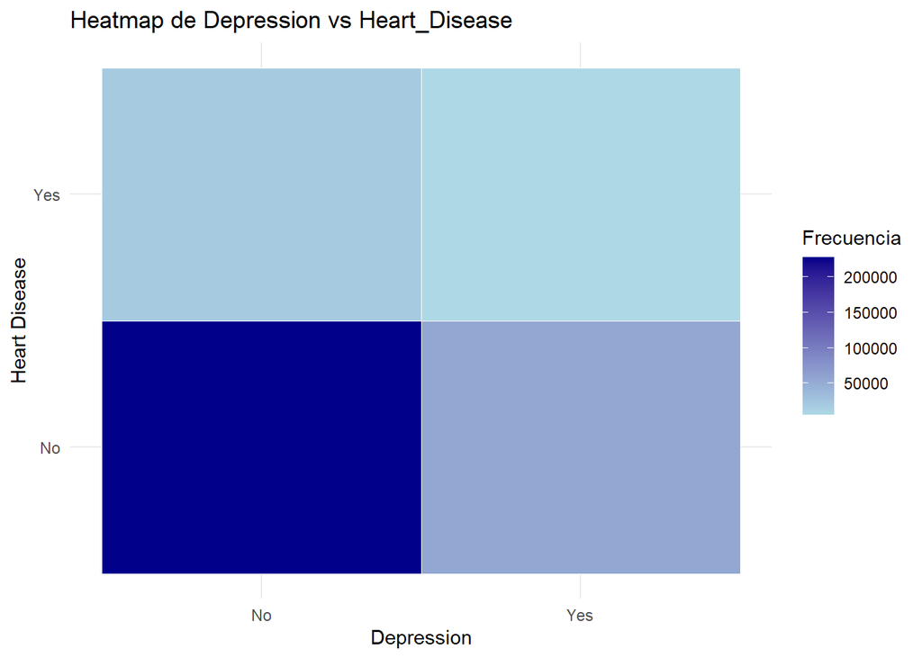

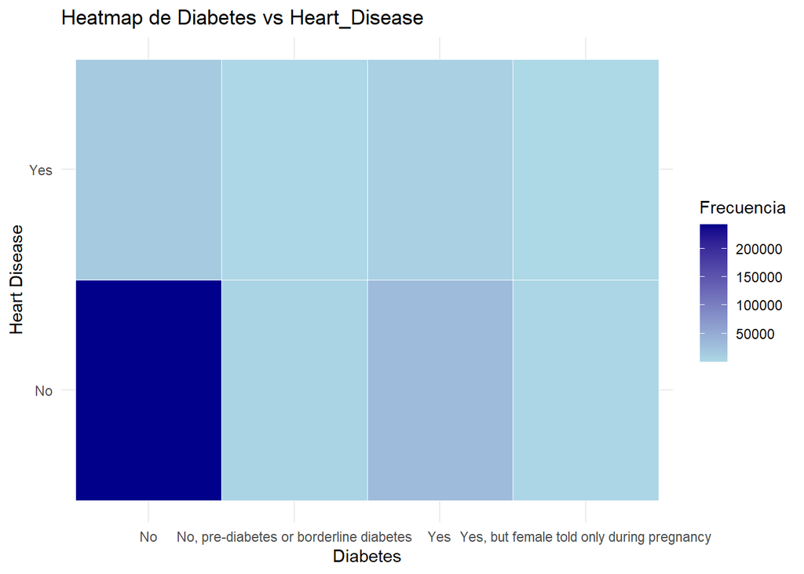

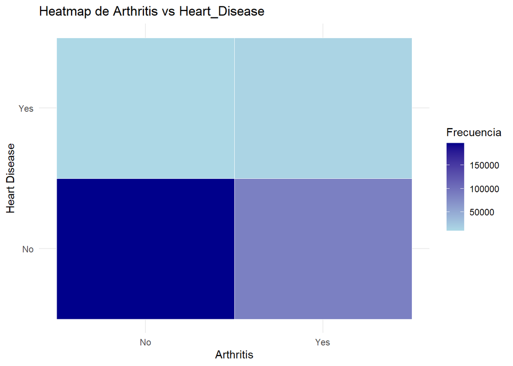

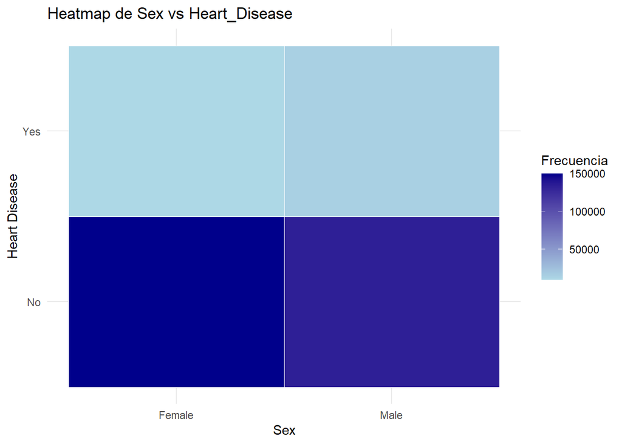

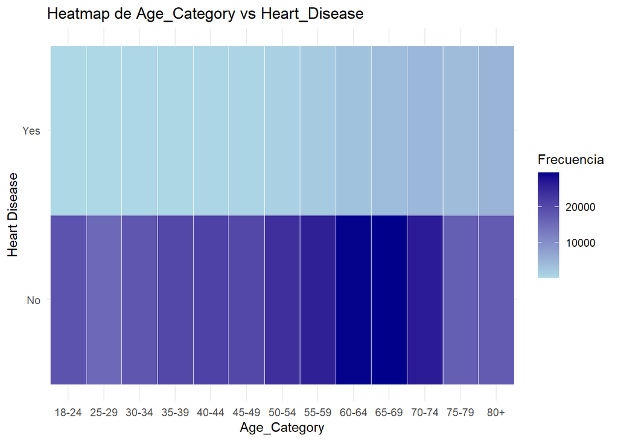

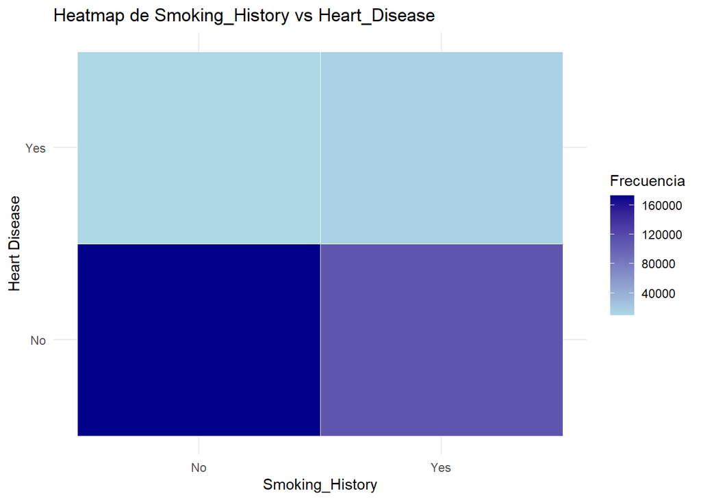

```r
# Crear un bucle para iterar sobre cada variable categórica
for (var in colnames(variables_categoricas)) {

  # Crear tabla de frecuencias
  tabla_frecuencias <- as.data.frame(table(data[[var]], data$Heart_Disease))
  colnames(tabla_frecuencias) <- c("Categoría", "Heart_Disease", "Frecuencia")

  # Graficar el heatmap
  g <- ggplot(tabla_frecuencias, aes(x = Categoría, y = Heart_Disease, fill = Frecuencia)) +
    geom_tile(color = "white") +  # Añadir bordes blancos a las celdas
    scale_fill_gradient(low = "lightblue", high = "darkblue") +  # Escala de colores
    labs(x = var, y = "Heart Disease", fill = "Frecuencia") +
    ggtitle(paste("Heatmap de", var, "vs Heart_Disease")) +
    theme_minimal()

  # Mostrar el heatmap
  print(g)
}
```

LOS HEATMAPS SON UNO DE LOS MÉTODOS DE VISUALIZACIÓN PARA VARIABLES CATEGORICAS MÁS CLAROS QUE EXISTEN. ADEMÁS, SON MUY FACILES DE INTERPRETAR, PUES SE NOS CREAN TANTAS CUADRAS COMO COMBINACIONES HAYA Y SE PONE UN COLOR SEGÚN LA FRECUENCIA.

## TRATAMIENTO OUTLIER

EN ESTE CASO, VAMOS A ELIMINARLOS YA QUE ESTÁN HACIENDO DEMASIADO RUIDO Y ESO PUEDE DISTORSIONAR MUCHO LOS RESULTADOS. NO OBSTANTE, VEREMOS SI NUESTROS MODELOS SON MEJORES O PEORES CUANDO NO TRATEMOS LOS OUTLIERS.

```r
# Cargar las librerías necesarias
library(dplyr)

# Definir las columnas numéricas para eliminar outliers
numeric_columns <- select_if(data, is.numeric) %>% colnames()

# Calcular el IQR para las columnas numéricas
Q1 <- apply(data[numeric_columns], 2, quantile, 0.25)
Q3 <- apply(data[numeric_columns], 2, quantile, 0.75)
IQR <- Q3 - Q1

# Establecer un valor umbral para la detección de outliers (por ejemplo, 1.5 veces el IQR)
threshold <- 1.5

# Crear una máscara para los outliers en las columnas numéricas
outlier_mask <- apply(data[numeric_columns], 1, function(row) {
  any(row < (Q1 - threshold * IQR) | row > (Q3 + threshold * IQR))
})

# Eliminar las filas con outliers del dataset
data_cleaned <- data[!outlier_mask, ]

# Imprimir el número de filas eliminadas
num_rows_removed <- nrow(data) - nrow(data_cleaned)
cat("Número de filas eliminadas debido a outliers:", num_rows_removed, "\n")
```

```
## Número de filas eliminadas debido a outliers: 124307
```

```r
dim(data_cleaned)
```

```
## [1] 184467     19
```

## RELACION VARIABLES

AQUI VAMOS A VER COMO LAS VARIABLES NUMERICAS Y CATEGORICAS SE CORRELACIONAN ENTRE SI Y SI PODEMOS ELIMINAR ALGUNA

### VARIABLES NUMERICAS

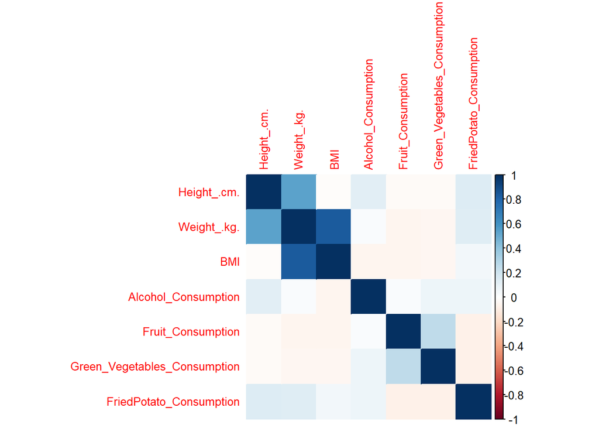

```r
variables_numericas_cleaned = data_cleaned %>%
  select(where(is.numeric))

# Hacemos la correlación de pearson
correlacion_numericas = cor(variables_numericas_cleaned,
                            method = "pearson",
                            use = "complete.obs") # ignora valores faltantes

# La visualizamos mediante corrplot
corrplot(correlacion_numericas, method = "color", tl.cex = 0.8)
```

ESTE CODIGO NOS PERMITE VER QUE VARIABLES ESTÁN ALTAMENTE CORRELACIONADAS EN, FUNCIÓN, DE UN PUNTO DE CORTE (cutoff) QUE SEÑALEMOS. LO NORMAL ES ENTRE 0.7-0.9

```r
# Paso 2: Encontrar índices de variables altamente correlacionadas
highly_correlated_indices <- findCorrelation(correlacion_numericas, cutoff = 0.8)

# Paso 3: Crear un nuevo conjunto de datos sin las variables altamente correlacionadas
variables_no_correlacionadas <- variables_numericas_cleaned[, -highly_correlated_indices]

# Verifica el nuevo conjunto de datos
head(variables_no_correlacionadas, 5)
```

```
##   Height_.cm.   BMI Alcohol_Consumption Fruit_Consumption
## 1         150 14.54                   0                30
## 2         165 28.29                   0                30
## 3         163 33.47                   4                12
## 4         180 28.73                   0                30
## 5         191 24.37                   0                 8
##   Green_Vegetables_Consumption FriedPotato_Consumption
## 1                           16                      12
## 2                            0                       4
## 3                            3                      16
## 4                           30                       8
## 5                            4                       0
```

Weight.kg y BMI ESTABAN MUY CORRELACIONADAS, ASI QUE SE ELIMINÓ Weight.kg

### VARIABLES CATEGORICAS

```r
# Extraemos solo las variables categóricas
variables_categoricas = data_cleaned %>%
  select(where(is.factor))

# Función para calcular el V de Cramer entre dos variables
calcular_cramer_v <- function(var1, var2) {
  tabla = table(var1, var2)
  resultado = assocstats(tabla)
  return(resultado$cramer)
}

# Crear una matriz vacía para almacenar los valores de V de Cramer
num_vars = ncol(variables_categoricas)
matriz_cramer = matrix(NA, nrow = num_vars, ncol = num_vars)
colnames(matriz_cramer) = colnames(variables_categoricas)
rownames(matriz_cramer) = colnames(variables_categoricas)

# Llenar la matriz con los valores de V de Cramer
for (i in 1:num_vars) {
  for (j in i:num_vars) {
    if (i == j) {
      matriz_cramer[i, j] = 1  # La correlación de una variable consigo misma es 1
    } else {
      cramer_v = calcular_cramer_v(variables_categoricas[[i]], variables_categoricas[[j]])
      matriz_cramer[i, j] = cramer_v
      matriz_cramer[j, i] = cramer_v  # La matriz es simétrica
    }
  }
}

# Mostrar la matriz
print(matriz_cramer)
```

```
##                 General_Health    Checkup   Exercise Heart_Disease Skin_Cancer
## General_Health      1.00000000 0.05591626 0.27823020    0.25654873  0.06422872
## Checkup             0.05591626 1.00000000 0.05010586    0.10095358  0.08771677
## Exercise            0.27823020 0.05010586 1.00000000    0.09772949  0.01575480
## Heart_Disease       0.25654873 0.10095358 0.09772949    1.00000000  0.09734765
## Skin_Cancer         0.06422872 0.08771677 0.01575480    0.09734765  1.00000000
## Other_Cancer        0.16036606 0.09696920 0.05941705    0.09705179  0.15196413
## Depression          0.20725426 0.03948199 0.08057332    0.03238282  0.00732437
## Diabetes            0.15977246 0.09221707 0.13685001    0.18900205  0.05307137
## Arthritis           0.27672847 0.16878399 0.12728128    0.15751429  0.13869463
## Sex                 0.03700764 0.10713870 0.08165789    0.07207228  0.01199490
## Age_Category        0.10151931 0.13723219 0.15040434    0.25249178  0.28513003
## Smoking_History     0.17439900 0.04239244 0.09215374    0.11702527  0.03419887
##                 Other_Cancer Depression   Diabetes Arthritis        Sex
## General_Health    0.16036606 0.20725426 0.15977246 0.2767285 0.03700764
## Checkup           0.09696920 0.03948199 0.09221707 0.1687840 0.10713870
## Exercise          0.05941705 0.08057332 0.13685001 0.1272813 0.08165789
## Heart_Disease     0.09705179 0.03238282 0.18900205 0.1575143 0.07207228
## Skin_Cancer       0.15196413 0.00732437 0.05307137 0.1386946 0.01199490
## Other_Cancer      1.00000000 0.01484830 0.07780209 0.1326169 0.03971993
## Depression        0.01484830 1.00000000 0.04729934 0.1290097 0.14539174
## Diabetes          0.07780209 0.04729934 1.00000000 0.1495505 0.09090831
## Arthritis         0.13261695 0.12900971 0.14955050 1.0000000 0.10949891
## Sex               0.03971993 0.14539174 0.09090831 0.1094989 1.00000000
## Age_Category      0.24890867 0.10417949 0.14900974 0.3826876 0.07112669
## Smoking_History   0.05593555 0.10568671 0.06588117 0.1324947 0.05506152
##                 Age_Category Smoking_History
## General_Health    0.10151931      0.17439900
## Checkup           0.13723219      0.04239244
## Exercise          0.15040434      0.09215374
## Heart_Disease     0.25249178      0.11702527
## Skin_Cancer       0.28513003      0.03419887
## Other_Cancer      0.24890867      0.05593555
## Depression        0.10417949      0.10568671
## Diabetes          0.14900974      0.06588117
## Arthritis         0.38268761      0.13249474
## Sex               0.07112669      0.05506152
## Age_Category      1.00000000      0.18538702
## Smoking_History   0.18538702      1.00000000
```

```r
#umbral = 0.6

# Identificar pares de variables altamente correlacionadas
#altamente_correlacionadas = which(matriz_cramer > umbral & matriz_cramer < 1, arr.ind = TRUE)

# Mostrar los pares de variables altamente correlacionadas
#for (i in 1:nrow(altamente_correlacionadas)) {
  #var1 = rownames(matriz_cramer)[altamente_correlacionadas[i, 1]]
  #var2 = colnames(matriz_cramer)[altamente_correlacionadas[i, 2]]
  #cat("Las variables", var1, "y", var2, "están altamente correlacionadas con un V de Cramer de", matriz_cramer[altamente_correlacionadas[i, 1], altamente_correlacionadas[i, #2]], "\n")
#}
```

ESTE CODIGO ESTA OCULTO, PERO ES PORQUE GENERA UN ERROR AL NO HABER VARIABLES CATEGORICAS ALTAMENTE CORRELACIONADAS. LO DEJO ASI PORQUE SI NO, NO ME DEJARIA EXPORTAR ESTE ARCHIVO A HTML.

## ENTRENAMIENTO MODELOS

ANTES DE CONSTRUIR Y EVALUAR MODELOS, DEBEMOS ESCALAR LAS VARIABLES NUMERICAS Y CATEGORICAS

### ESCALADO DE VARIABLES

NUMERICAS

```r
# Scale dataset

# Paso 1: Calcular parámetros de preprocesamiento
normParams <- preProcess(variables_no_correlacionadas, method=c("range"))

# Paso 2: Imprimir los parámetros de preprocesamiento
print(normParams)
```

```
## Created from 184467 samples and 6 variables
##
## Pre-processing:
##   - ignored (0)
##   - re-scaling to [0, 1] (6)
```

```r
# Paso 3: Transformar el nuevo conjunto de datos
variables_numericas_e <- predict(normParams, variables_no_correlacionadas)

# Vamos a ver como quedaron las variables numericas escaladas
summary(variables_numericas_e)
```

```
##   Height_.cm.          BMI         Alcohol_Consumption Fruit_Consumption
##  Min.   :0.0000   Min.   :0.0000   Min.   :0.0000      Min.   :0.0000
##  1st Qu.:0.3621   1st Qu.:0.3768   1st Qu.:0.0000      1st Qu.:0.1429
##  Median :0.4828   Median :0.4798   Median :0.0000      Median :0.2857
##  Mean   :0.4881   Mean   :0.5040   Mean   :0.1673      Mean   :0.3297
##  3rd Qu.:0.6207   3rd Qu.:0.6149   3rd Qu.:0.2667      3rd Qu.:0.5357
##  Max.   :1.0000   Max.   :1.0000   Max.   :1.0000      Max.   :1.0000
##  Green_Vegetables_Consumption FriedPotato_Consumption
##  Min.   :0.00000              Min.   :0.0000
##  1st Qu.:0.09091              1st Qu.:0.1176
##  Median :0.20455              Median :0.2353
##  Mean   :0.27055              Mean   :0.2873
##  3rd Qu.:0.36364              3rd Qu.:0.4706
##  Max.   :1.00000              Max.   :1.0000
```

CATEGORICAS BINARIAS

```r
data_cleaned$Heart_Disease = ifelse(data_cleaned$Heart_Disease == "Yes", 1,0)
data_cleaned$Exercise = ifelse(data_cleaned$Exercise == "Yes", 1,0)
data_cleaned$Skin_Cancer = ifelse(data_cleaned$Skin_Cancer == "Yes", 1,0)
data_cleaned$Other_Cancer = ifelse(data_cleaned$Other_Cancer == "Yes", 1,0)
data_cleaned$Depression = ifelse(data_cleaned$Depression == "Yes", 1,0)
data_cleaned$Arthritis = ifelse(data_cleaned$Arthritis == "Yes", 1,0)
data_cleaned$Sex = ifelse(data_cleaned$Sex == "Female", 1,0)
data_cleaned$Smoking_History = ifelse(data_cleaned$Smoking_History == "Yes", 1,0)
```

CONVETIMOS NUESTRA VARIABLE TARGET A FACTOR PARA UN MEJOR RENDIMIENTO DE LOS MODELOS

```r
data_cleaned$Heart_Disease = as.factor(data_cleaned$Heart_Disease)
```

CATEGORICAS ORDINALES

PRIMERO VAMOS A VER LOS NIVELES DE CADA VARIABLE PARA LUEGO ESCALARLA CORRECTAMENTE

```r
niveles_General_Health = levels(data_cleaned$General_Health)
niveles_General_Health
```

```
## [1] "Excellent" "Fair"      "Good"      "Poor"      "Very Good"
```

```r
niveles_Checkup = levels(data_cleaned$Checkup)
niveles_Checkup
```

```
## [1] "5 or more years ago"     "Never"
## [3] "Within the past 2 years" "Within the past 5 years"
## [5] "Within the past year"
```

```r
niveles_Age_Category = levels(data_cleaned$Age_Category)
niveles_Age_Category
```

```
##  [1] "18-24" "25-29" "30-34" "35-39" "40-44" "45-49" "50-54" "55-59" "60-64"
## [10] "65-69" "70-74" "75-79" "80+"
```

```r
niveles_Diabetes = levels(data_cleaned$Diabetes)
niveles_Diabetes # Incluyo aqui diabetes solo para saber los niveles, no voy a escalarla como una variable categorica ordinal
```

```
## [1] "No"
## [2] "No, pre-diabetes or borderline diabetes"
## [3] "Yes"
## [4] "Yes, but female told only during pregnancy"
```

AHORA LAS ESCALAMOS

```r
# Escalando la variable ordinal General_Health
data_cleaned <- data_cleaned %>%
  mutate(General_Health = factor(General_Health, levels = c("Poor", "Fair", "Good", "Very Good", "Excellent"),
                        labels = c(1, 2, 3, 4, 5), ordered = TRUE))

# Escalando la variable ordinal Checkup
data_cleaned <- data_cleaned %>%
  mutate(Checkup = factor(Checkup, levels = c("Never", "5 or more years ago", "Within the past 5 years", "Within the past 2 years", "Within the past year"),
                        labels = c(1, 2, 3, 4, 5), ordered = TRUE))

# Escalando la variable ordinal Checkup
data_cleaned <- data_cleaned %>%
  mutate(Age_Category = factor(Age_Category, levels = c("18-24", "25-29", "30-34", "35-39", "40-44", "45-49", "50-54", "55-59", "60-64", "65-69", "70-74", "75-79", "80+"),
                        labels = c(1, 2, 3, 4, 5, 6, 7, 8, 9, 10, 11, 12, 13), ordered = TRUE))
```

VARIABLES CATEGORICAS NOMINALES

```r
# Asegúrate de que Diabetes es un factor
data_cleaned$Diabetes <- as.factor(data_cleaned$Diabetes)

# Aplicar la codificación one-hot
diabetes_dummies <- model.matrix(~ Diabetes - 1, data = data_cleaned)

# Convertir a data frame
diabetes_dummies <- as.data.frame(diabetes_dummies)

# Combinar el nuevo DataFrame con las variables restantes
data_cleaned <- data_cleaned %>%
  select(-Diabetes)  # Eliminar la columna original de Diabetes
```

POR ÚLTIMO, UNIMOS LAS NUEVAS VARIABLES NUMERICAS ESCALADAS CON LAS CATEGORICAS ESCALADAS

```r
# Primero quitamos las variables numericas originales del dataset
numerical_cols <- sapply(data_cleaned, is.numeric)
data_cleaned_non_numeric <- data_cleaned[, !numerical_cols]

# Uno las variables numericas escaladas con el resto del dataset
nuevo_dataset = cbind(variables_numericas_e, data_cleaned_non_numeric, diabetes_dummies)


str(nuevo_dataset)
```

```
## 'data.frame':    184467 obs. of  14 variables:
##  $ Height_.cm.                                       : num  0.138 0.397 0.362 0.655 0.845 ...
##  $ BMI                                               : num  0.0549 0.5071 0.6774 0.5215 0.3782 ...
##  $ Alcohol_Consumption                               : num  0 0 0.267 0 0 ...
##  $ Fruit_Consumption                                 : num  0.536 0.536 0.214 0.536 0.143 ...
##  $ Green_Vegetables_Consumption                      : num  0.3636 0 0.0682 0.6818 0.0909 ...
##  $ FriedPotato_Consumption                           : num  0.706 0.235 0.941 0.471 0 ...
##  $ General_Health                                    : Ord.factor w/ 5 levels "1"<"2"<"3"<"4"<..: 1 4 4 1 3 2 3 2 2 2 ...
##  $ Checkup                                           : Ord.factor w/ 5 levels "1"<"2"<"3"<"4"<..: 4 5 5 5 5 5 5 5 5 5 ...
##  $ Heart_Disease                                     : Factor w/ 2 levels "0","1": 1 2 1 2 1 2 1 1 1 2 ...
##  $ Age_Category                                      : Ord.factor w/ 13 levels "1"<"2"<"3"<"4"<..: 11 11 9 12 13 9 10 10 11 12 ...
##  $ DiabetesNo                                        : num  1 0 0 0 1 1 1 1 0 1 ...
##  $ DiabetesNo, pre-diabetes or borderline diabetes   : num  0 0 0 0 0 0 0 0 0 0 ...
##  $ DiabetesYes                                       : num  0 1 1 1 0 0 0 0 1 0 ...
##  $ DiabetesYes, but female told only during pregnancy: num  0 0 0 0 0 0 0 0 0 0 ...
```

HACEMOS UN SUMMARY RAPIDO PARA VER COMO QUEDAN

```r
summary(nuevo_dataset)
```

```
##   Height_.cm.          BMI         Alcohol_Consumption Fruit_Consumption
##  Min.   :0.0000   Min.   :0.0000   Min.   :0.0000      Min.   :0.0000
##  1st Qu.:0.3621   1st Qu.:0.3768   1st Qu.:0.0000      1st Qu.:0.1429
##  Median :0.4828   Median :0.4798   Median :0.0000      Median :0.2857
##  Mean   :0.4881   Mean   :0.5040   Mean   :0.1673      Mean   :0.3297
##  3rd Qu.:0.6207   3rd Qu.:0.6149   3rd Qu.:0.2667      3rd Qu.:0.5357
##  Max.   :1.0000   Max.   :1.0000   Max.   :1.0000      Max.   :1.0000
##
##  Green_Vegetables_Consumption FriedPotato_Consumption General_Health Checkup
##  Min.   :0.00000              Min.   :0.0000          1: 6980        1:   858
##  1st Qu.:0.09091              1st Qu.:0.1176          2:22213        2:  7800
##  Median :0.20455              Median :0.2353          3:58884        3: 10408
##  Mean   :0.27055              Mean   :0.2873          4:65406        4: 22151
##  3rd Qu.:0.36364              3rd Qu.:0.4706          5:30984        5:143250
##  Max.   :1.00000              Max.   :1.0000
##
##  Heart_Disease  Age_Category     DiabetesNo
##  0:168737      10     :19746   Min.   :0.0000
##  1: 15730      9      :19210   1st Qu.:1.0000
##                11     :18719   Median :1.0000
##                8      :16650   Mean   :0.8331
##                7      :14850   3rd Qu.:1.0000
##                13     :13776   Max.   :1.0000
##                (Other):81516
##  DiabetesNo, pre-diabetes or borderline diabetes  DiabetesYes
##  Min.   :0.00000                                 Min.   :0.0000
##  1st Qu.:0.00000                                 1st Qu.:0.0000
##  Median :0.00000                                 Median :0.0000
##  Mean   :0.02317                                 Mean   :0.1353
##  3rd Qu.:0.00000                                 3rd Qu.:0.0000
##  Max.   :1.00000                                 Max.   :1.0000
##
##  DiabetesYes, but female told only during pregnancy
##  Min.   :0.000000
##  1st Qu.:0.000000
##  Median :0.000000
##  Mean   :0.008457
##  3rd Qu.:0.000000
##  Max.   :1.000000
##
```

### PARTICION DE LOS DATOS

```r
set.seed(123)

# Preparar datos
train_index <- createDataPartition(nuevo_dataset$Heart_Disease, p = 0.8, list = FALSE)
train_data <- nuevo_dataset[train_index, ]
test_data <- nuevo_dataset[-train_index, ]
```

### ENTRENAMIENTO MODELOS - VALIDACIÓN CRUZADA

```r
train_control <- trainControl(method = "repeatedcv", number = 10, repeats = 3)

# Ajustar el modelo de regresión logística con validación cruzada
modelo_logistico <- train(Heart_Disease ~ ., data = train_data, method = "glm",
                          family = "binomial", trControl = train_control)

# Imprimir resultados de los modelos
print(modelo_logistico)
```

```
## Generalized Linear Model
##
## 147574 samples
##     13 predictor
##      2 classes: '0', '1'
##
## No pre-processing
## Resampling: Cross-Validated (10 fold, repeated 3 times)
## Summary of sample sizes: 132817, 132816, 132817, 132817, 132817, 132817, ...
## Resampling results:
##
##   Accuracy   Kappa
##   0.9144497  0.07320674
```

BIEN, UNA VEZ OBTENIDOS LOS RESULTADOS, VAMOS A HACERLO SIN EL TRATAMIENTO DE OUTLIERS Y VEAMOS QUE MODELO PARECE TENER UN ACCURACY MÁS ALTO Y UN KAPPA MÁS PEQUEÑO. CABE DESTACAR QUE PARA ESTE PROYECTO SOLO UTILIZAREMOS EL MODELO LOGISTICO, PUES AL TRATARSE DE UN VOLUMEN TAN GRANDE DE DATOS, MODELOS COMO RANDOM FOREST O SUPPORT VECTOR MACHINE ME TARDAN DEMASIADO. NO OBSTANTE, DEJO QUE CUALQUIERA DE LOS QUE VEAN ESTE PROYECTO, SE ANIMEN Y COMPARTAN SUS RESULTADOS CON OTROS MODELOS PREDICTIVOS.

### CONSTRUCCION Y EVALUACION DE MODELO CON OUTLIERS

EMPEZAREMOS DESDE LA RELACION DE LAS VARIABLES, QUE ES CUANDO CAMBIAMOS DE DATA A DATA_CLEANED Y SEGUIREMOS LOS MISMOS PASOS

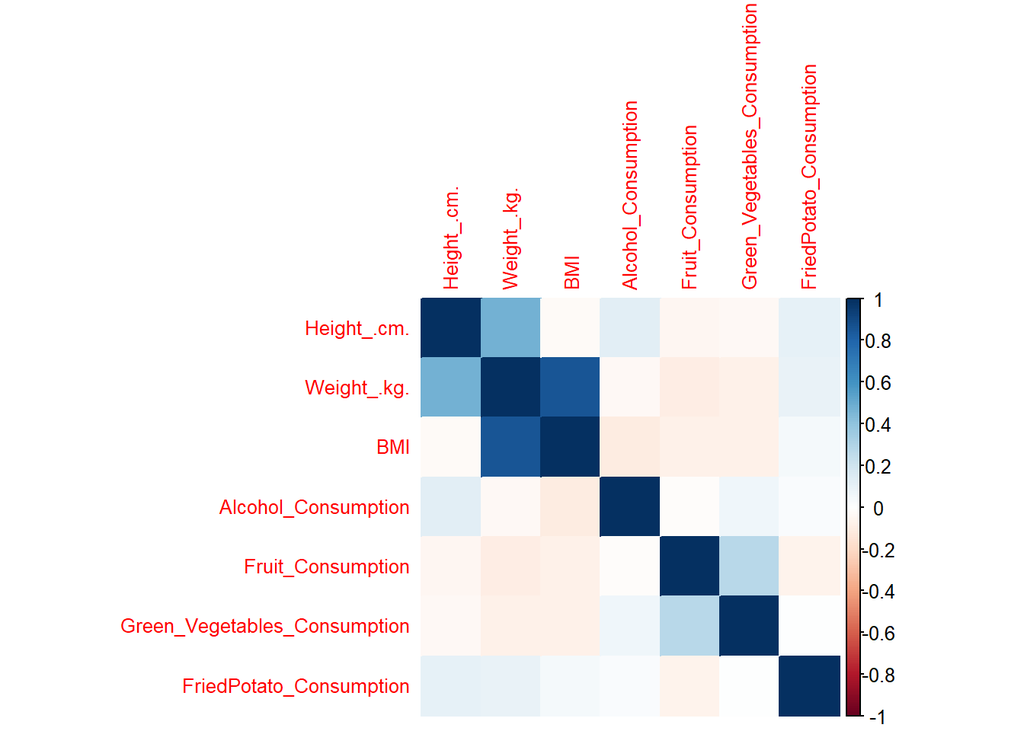

```r
variables_numericas = data %>%
  select(where(is.numeric))

# Hacemos la correlación de pearson
correlacion_numericas_2 = cor(variables_numericas,
                            method = "pearson",
                            use = "complete.obs") # ignora valores faltantes

# La visualizamos mediante corrplot
corrplot(correlacion_numericas_2, method = "color", tl.cex = 0.8)
```

```r
# Paso 2: Encontrar índices de variables altamente correlacionadas
highly_correlated_indices_2 <- findCorrelation(correlacion_numericas_2, cutoff = 0.8)

# Paso 3: Crear un nuevo conjunto de datos sin las variables altamente correlacionadas
variables_no_correlacionadas_2 <- variables_numericas[, -highly_correlated_indices_2]

# Verifica el nuevo conjunto de datos
head(variables_no_correlacionadas_2, 5)
```

```
##   Height_.cm.   BMI Alcohol_Consumption Fruit_Consumption
## 1         150 14.54                   0                30
## 2         165 28.29                   0                30
## 3         163 33.47                   4                12
## 4         180 28.73                   0                30
## 5         191 24.37                   0                 8
##   Green_Vegetables_Consumption FriedPotato_Consumption
## 1                           16                      12
## 2                            0                       4
## 3                            3                      16
## 4                           30                       8
## 5                            4                       0
```

NOS SALTAMOS EL PASO DE LAS VARIABLES CATEGORICAS PORQUE YA VIMOS QUE NINGUNA ESTA ALTAMENTE CORRELACIONADA.

ESCALADO VARIABLES NUMERICAS

```r
# Scale dataset

# Paso 1: Calcular parámetros de preprocesamiento
normParams_2 <- preProcess(variables_no_correlacionadas_2, method=c("range"))

# Paso 2: Imprimir los parámetros de preprocesamiento
print(normParams_2)
```

```
## Created from 308774 samples and 6 variables
##
## Pre-processing:
##   - ignored (0)
##   - re-scaling to [0, 1] (6)
```

```r
# Paso 3: Transformar el nuevo conjunto de datos
variables_numericas_e_2 <- predict(normParams_2, variables_no_correlacionadas_2)

# Vamos a ver como quedaron las variables numericas escaladas
summary(variables_numericas_e_2)
```

```
##   Height_.cm.          BMI         Alcohol_Consumption Fruit_Consumption
##  Min.   :0.0000   Min.   :0.0000   Min.   :0.00000     Min.   :0.0000
##  1st Qu.:0.4800   1st Qu.:0.1396   1st Qu.:0.00000     1st Qu.:0.1000
##  Median :0.5267   Median :0.1766   Median :0.03333     Median :0.2500
##  Mean   :0.5308   Mean   :0.1902   Mean   :0.16992     Mean   :0.2486
##  3rd Qu.:0.5800   3rd Qu.:0.2271   3rd Qu.:0.20000     3rd Qu.:0.2500
##  Max.   :1.0000   Max.   :1.0000   Max.   :1.00000     Max.   :1.0000
##  Green_Vegetables_Consumption FriedPotato_Consumption
##  Min.   :0.00000              Min.   :0.00000
##  1st Qu.:0.03125              1st Qu.:0.01562
##  Median :0.09375              Median :0.03125
##  Mean   :0.11804              Mean   :0.04920
##  3rd Qu.:0.15625              3rd Qu.:0.06250
##  Max.   :1.00000              Max.   :1.00000
```

ESCALADO VARIABLES CATEGORICAS BINARIAS

```r
data$Heart_Disease = ifelse(data$Heart_Disease == "Yes", 1,0)
data$Exercise = ifelse(data$Exercise == "Yes", 1,0)
data$Skin_Cancer = ifelse(data$Skin_Cancer == "Yes", 1,0)
data$Other_Cancer = ifelse(data$Other_Cancer == "Yes", 1,0)
data$Depression = ifelse(data$Depression == "Yes", 1,0)
data$Arthritis = ifelse(data$Arthritis == "Yes", 1,0)
data$Sex = ifelse(data$Sex == "Female", 1,0)
data$Smoking_History = ifelse(data$Smoking_History == "Yes", 1,0)
```

CONVERTIMOS NUESTRA VARIABLE TARGET A FACTOR PARA UN MEJOR RENDIMIENTO DE LOS MODELOS

```r
data$Heart_Disease = as.factor(data$Heart_Disease)
```

ESCALADO VARIABLES CATEGORICAS ORDINALES

```r
# Escalando la variable ordinal General_Health
data <- data %>%
  mutate(General_Health = factor(General_Health, levels = c("Poor", "Fair", "Good", "Very Good", "Excellent"),
                        labels = c(1, 2, 3, 4, 5), ordered = TRUE))

# Escalando la variable ordinal Checkup
data <- data %>%
  mutate(Checkup = factor(Checkup, levels = c("Never", "5 or more years ago", "Within the past 5 years", "Within the past 2 years", "Within the past year"),
                        labels = c(1, 2, 3, 4, 5), ordered = TRUE))

# Escalando la variable ordinal Checkup
data <- data %>%
  mutate(Age_Category = factor(Age_Category, levels = c("18-24", "25-29", "30-34", "35-39", "40-44", "45-49", "50-54", "55-59", "60-64", "65-69", "70-74", "75-79", "80+"),
                        labels = c(1, 2, 3, 4, 5, 6, 7, 8, 9, 10, 11, 12, 13), ordered = TRUE))
```

ESCALADO VARIABLES CATEGORICAS NOMINALES

```r
# Asegúrate de que Diabetes es un factor
data$Diabetes <- as.factor(data$Diabetes)

# Aplicar la codificación one-hot
diabetes_dummies <- model.matrix(~ Diabetes - 1, data = data)

# Convertir a data frame
diabetes_dummies <- as.data.frame(diabetes_dummies)

# Combinar el nuevo DataFrame con las variables restantes
data <- data %>%
  select(-Diabetes)  # Eliminar la columna original de Diabetes
```

POR ÚLTIMO, UNIMOS LAS NUEVAS VARIABLES NUMERICAS ESCALADAS CON LAS CATEGORICAS ESCALADAS

```r
# Primero quitamos las variables numericas originales del dataset
numerical_cols <- sapply(data, is.numeric)
data_non_numeric <- data[, !numerical_cols]

# Uno las variables numericas escaladas con el resto del dataset
nuevo_dataset_2 = cbind(variables_numericas_e_2, data_non_numeric, diabetes_dummies)


str(nuevo_dataset_2)
```

```
## 'data.frame':    308774 obs. of  14 variables:
##  $ Height_.cm.                                       : num  0.393 0.493 0.48 0.593 0.667 ...
##  $ BMI                                               : num  0.0289 0.1863 0.2457 0.1914 0.1415 ...
##  $ Alcohol_Consumption                               : num  0 0 0.133 0 0 ...
##  $ Fruit_Consumption                                 : num  0.25 0.25 0.1 0.25 0.0667 ...
##  $ Green_Vegetables_Consumption                      : num  0.125 0 0.0234 0.2344 0.0312 ...
##  $ FriedPotato_Consumption                           : num  0.0938 0.0312 0.125 0.0625 0 ...
##  $ General_Health                                    : Ord.factor w/ 5 levels "1"<"2"<"3"<"4"<..: 1 4 4 1 3 3 2 3 2 2 ...
##  $ Checkup                                           : Ord.factor w/ 5 levels "1"<"2"<"3"<"4"<..: 4 5 5 5 5 5 5 5 5 5 ...
##  $ Heart_Disease                                     : Factor w/ 2 levels "0","1": 1 2 1 2 1 1 2 1 1 1 ...
##  $ Age_Category                                      : Ord.factor w/ 13 levels "1"<"2"<"3"<"4"<..: 11 11 9 12 13 9 9 10 10 11 ...
##  $ DiabetesNo                                        : num  1 0 0 0 1 1 1 1 1 0 ...
##  $ DiabetesNo, pre-diabetes or borderline diabetes   : num  0 0 0 0 0 0 0 0 0 0 ...
##  $ DiabetesYes                                       : num  0 1 1 1 0 0 0 0 0 1 ...
##  $ DiabetesYes, but female told only during pregnancy: num  0 0 0 0 0 0 0 0 0 0 ...
```

```r
set.seed(123)

# Preparar datos
train_index <- createDataPartition(nuevo_dataset_2$Heart_Disease, p = 0.8, list = FALSE)
train_data <- nuevo_dataset_2[train_index, ]
test_data <- nuevo_dataset_2[-train_index, ]
```

```r
train_control <- trainControl(method = "repeatedcv", number = 10, repeats = 3)

# Ajustar el modelo de regresión logística con validación cruzada
modelo_logistico_2 <- train(Heart_Disease ~ ., data = train_data, method = "glm",
                          family = "binomial", trControl = train_control)

# Imprimir resultados de los modelos
print(modelo_logistico_2)
```

```
## Generalized Linear Model
##
## 247020 samples
##     13 predictor
##      2 classes: '0', '1'
##
## No pre-processing
## Resampling: Cross-Validated (10 fold, repeated 3 times)
## Summary of sample sizes: 222318, 222317, 222318, 222318, 222319, 222319, ...
## Resampling results:
##
##   Accuracy  Kappa
##   0.918985  0.06686474
```

## RESULTADOS Y CONCLUSIONES

```r
library(gt)

# Extraer las métricas de desempeño
resultado_logistico <- data.frame(
  Modelo = "Logístico (sin outliers)",
  Accuracy = modelo_logistico$results$Accuracy,
  Kappa = modelo_logistico$results$Kappa
)

resultado_logistico_2 <- data.frame(
  Modelo = "Logístico (con outliers)",
  Accuracy = modelo_logistico_2$results$Accuracy,
  Kappa = modelo_logistico_2$results$Kappa
)

# Unir los resultados en una tabla
resultados_completos <- rbind(resultado_logistico, resultado_logistico_2)

# Crear una tabla estilizada con gt
resultados_completos %>%
  gt() %>%
  tab_header(
    title = "Comparación de Modelos Logísticos"
  ) %>%
  tab_spanner(
    label = "Desempeño",
    columns = vars(Accuracy, Kappa)
  ) %>%
  fmt_number(
    columns = vars(Accuracy, Kappa),
    decimals = 3
  ) %>%
  tab_style(
    style = list(
      cell_borders(sides = "all", color = "gray", weight = 1),
      cell_text(weight = "bold")
    ),
    locations = cells_title()
  ) %>%
  tab_style(
    style = list(
      cell_fill(color = "lightgray")
    ),
    locations = cells_body(columns = everything())
  ) %>%
  tab_style(
    style = list(
      cell_text(align = "center")
    ),
    locations = cells_column_labels()
  )
```

Comparación de Modelos Logísticos

| Modelo | Desempeño Accuracy | Desempeño Kappa |
| --- | --- | --- |
| Logístico (sin outliers) | 0.914 | 0.073 |
| Logístico (con outliers) | 0.919 | 0.067 |

OTRA FORMA DE PRESENTAR LOS RESULTADOS

```r
# Extraer las métricas de desempeño
resultado_logistico <- data.frame(
  Modelo = "Logístico (sin outliers)",
  Accuracy = modelo_logistico$results$Accuracy,
  Kappa = modelo_logistico$results$Kappa
)

resultado_logistico_2 <- data.frame(
  Modelo = "Logístico (con outliers)",
  Accuracy = modelo_logistico_2$results$Accuracy,
  Kappa = modelo_logistico_2$results$Kappa
)

# Unir los resultados en una tabla
resultados_completos <- rbind(resultado_logistico, resultado_logistico_2)

# Crear una tabla con kableExtra
resultados_completos %>%
  kable("html", col.names = c("Modelo", "Accuracy", "Kappa"), caption = "Comparación de Modelos Logísticos") %>%
  kable_styling(
    bootstrap_options = c("striped", "hover", "responsive"),
    font_size = 14,
    position = "center",
    full_width = F
  ) %>%
  column_spec(1, bold = TRUE, color = "white", background = "#4CAF50") %>%  # Verde más suave
  column_spec(2:3, color = "black", background = "#E8F5E9") %>%  # Fondo claro y texto negro
  row_spec(0, bold = TRUE, color = "white", background = "#388E3C") %>%  # Fila de encabezado en verde oscuro
  add_header_above(c(" " = 1, "Desempeño" = 2))
```

Comparación de Modelos Logísticos

| Modelo | Desempeño Accuracy | Desempeño Kappa |
| --- | --- | --- |
| Logístico (sin outliers) | 0.9144497 | 0.0732067 |
| Logístico (con outliers) | 0.9189850 | 0.0668647 |

RESULTADOS **MODELO LOGISTICO SIN OUTLIERS:**

VEMOS QUE TIENE UNA PRECISION (ACCURACY) DE 0.914, LO CUAL ES BASTANTE ALTO, JUNTO CON UN VALOR KAPPA (TAMBIEN CONOCIDO COMO INDICE DE KAPPA DE COHEN) DE 0.073. KAPPA ES UNA MEDIDA DE LA CONSISTENCIA O ACUERDO ENTRE DOS OBSERVADORES O CLASIFICADORES, COMO ES EL CASO DE NUESTRA VARIABLE TARGET QUE NOS DICE SI PRESENTAN O NO ENFERMEDAD CARDIOVASCULAR. ESTE VALOR BAJO SIGNIFICA QUE EL MODELO PREDICE DE FORMA PRECISA PERO DE FORMA ALEATORIA EN LA MAYORIA DE CASOS (por ejemplo, al predecir la clase mayoritaria con alta frecuencia), LO QUE NO REFLEJA UN VERDADERO ACUERDO SIGNIFICATIVO CON LAS CLASES REALES (SI / NO).

RESULTADOS **MODELO LOGISTICO CON OUTLIERS:**

VEMOS, QUE DE IGUAL FORMA QUE EL MODELO SIN OUTLIERS, TIENE UNA PRECISION (ACCURACY) DE 0.918, LO CUAL ES BASTANTE ALTO TAMBIÉN, JUNTO CON UN VALOR KAPPA DE 0.066.

**¿QUE ESTÁ OCURRIENDO?**

PUEDE HABER VARIAS EXPLICACIONES ANTE ESTE SUCESO:

**Clase desbalanceada:** Si el conjunto de datos tiene una distribución desequilibrada entre las clases (por ejemplo, muchas más instancias de una clase que de la otra), el modelo podría predecir correctamente la clase mayoritaria con frecuencia, lo que eleva el accuracy pero no refleja un acuerdo real con la clase minoritaria.

**Modelo sobreajustado o poco informativo:** Aunque el modelo tiene un accuracy alto, podría no estar capturando bien la información para las predicciones de la clase minoritaria o los casos más complejos. El bajo Kappa indica que las predicciones no están completamente alineadas con las clases reales, más allá de lo que ocurriría por azar.

SI NOS VAMOS A LA VARIABLE TARGET Y SU CONTEO, OBSERVAMOS QUE, EFECTIVAMENTE, HAY 283.803 CASOS NEGATIVOS Y TAN SOLO 24.971 POSITIVOS. ESTO HACE QUE LA DISTRIBUCIÓN ESTÉ MUY DESBALANCEADA, EXPLICANDO UN ALTO ACCURACY (PROBABLEMENTE PARA LOS CASOS NEGATIVOS) Y UN VALOR BAJO DE KAPPA. ES DECIR, AL HABER TANTISIMOS CASOS NEGATIVOS, EL SIMPLE AZAR HACE QUE NUESTRO MODELO PREDIGA BIEN, PUES LA MAYORIA DE ESTOS SON NEGATIVOS. SI TUVIERAMOS UN BALANCE ENTRE LAS CLASES, PODRIAMOS VER SI EFECTIVAMENTE EL MODELO FUNCIONA CORRECTAMENTE O NO.

¿QUE PODRIAMOS HACER PARA ARREGLAR ESTO?

TENEMOS TRES POSIBLES SOLUCIONES:

1º- **AJUSTE DE PESOS EN EL MODELO:** APROVECHANDO QUE LA REGRESION LOGITICA PERMITE ASIGNAR DIFERENTES PESOS A LAS CLASES, PODRIAMOS DARLE MÁS PESO A LA CLASE POSITIVA (MINORITARIA) PARA QUE EL MODELO SE ENFOQUE MÁS EN PREDECIR ESTOS CASOS, HACIENDO QUE NO SE FAVOREZCA TANTO LA CLASE NEGATIVA (MAYORITARIA)

2º- **SUBMUESTREO O SOBREMUETREO:** OTRA POSIBLE SOLUCIÓN SERIA REDUCIR EL NUMERO DE CASOS NEGATIVOS O, POR EL CONTRARIO, AUMENTAR EL NUMERO DE CASOS POSITIVOS Y REPETIR EL ANÁLISIS

3º- **METRICAS ADICIONALES:** PODRIAMOS AÑADIR A NUESTRO MODELOS OTRAS METRICAS COMO RECALL, F1-SCORE, ETC YA QUE LA PRECISIÓN NO SIEMPRE VA A SER UN BUEN INDICATIVO, COMO HEMOS VISTO, DEL DESEMPEÑO.

VAMOS A APLICAR LA PRIMERA SOLUCION, QUE ES LA QUE MÁS FACIL NOS PERMITE R, PARA COMPROBAR SI NUESTRO MODELO MEJORA

## SOLUCION A NUESTRO MODELO

ES UN BUEN MOMENTO PARA EXPLICAR QUE, EN UN PRINCIPIO, LOS OUTLIERS NO ESTÁN AFECTANDO A NUESTROS MODELOS, ASI QUE VAMOS A PODER HACER ESTAS PRUEBAS CON CUALQUIERA DE LOS DOS.

```r
# Crear un vector de pesos donde asignamos más peso a la clase positiva
pesos <- ifelse(train_data$Heart_Disease == 1, 5, 1)  # Aquí el 5 es el peso para la clase positiva

# Ajustar el modelo logístico con pesos
modelo_logistico_3 <- train(Heart_Disease ~ ., data = train_data, method = "glm",
                          family = "binomial", trControl = train_control,
                          weights = pesos)

# Imprimir resultados de los modelos
print(modelo_logistico_3)
```

```
## Generalized Linear Model
##
## 247020 samples
##     13 predictor
##      2 classes: '0', '1'
##
## No pre-processing
## Resampling: Cross-Validated (10 fold, repeated 3 times)
## Summary of sample sizes: 222318, 222317, 222319, 222318, 222318, 222319, ...
## Resampling results:
##
##   Accuracy   Kappa
##   0.8516935  0.2789731
```

DE ACUERDO, SI BIEN ES CIERTO QUE EL ACCURACY HA BAJADO, EL VALOR DE KAPPA HA AUMENTADO CONSIDERABLEMENTE. EN ESTE CASO, LE HEMOS DADO UN VALOR DE 5 PARA AUMENTAR LA CLASE MINORITARIA, SI JUGAMOS CON EL PESO QUE LE DAMOS, PODRIAMOS LLEGAR A OBTENER MEJORES RESULTADOS.

VAMOS A PONER PESOS DISTINTOS

```r
# Crear un vector de pesos donde asignamos más peso a la clase positiva
pesos <- ifelse(train_data$Heart_Disease == 1, 6, 1)  # Ponemos 6 en vez de 5

# Ajustar el modelo logístico con pesos
modelo_logistico_4 <- train(Heart_Disease ~ ., data = train_data, method = "glm",
                          family = "binomial", trControl = train_control,
                          weights = pesos)

# Imprimir resultados de los modelos
print(modelo_logistico_4)
```

```
## Generalized Linear Model
##
## 247020 samples
##     13 predictor
##      2 classes: '0', '1'
##
## No pre-processing
## Resampling: Cross-Validated (10 fold, repeated 3 times)
## Summary of sample sizes: 222318, 222318, 222318, 222318, 222319, 222317, ...
## Resampling results:
##
##   Accuracy  Kappa
##   0.829277  0.2698066
```

VEMOS QUE AÑADIENDO MÁS PESO, KAPPA DISMINUYE, ESTO ES PROBABLE QUE SEA PORQUE PROPORCIONALMENTE AHORA ESTÁ SIENDO LA CLASE MAYORITARIA LA POSITIVA.

ESTE DATASET HA SIDO COGIDO DE KAGGLE, POR LO QUE YO SOLO DOY EXPLICACIÓN A LO QUE TENGO EN MIS MANOS.